# Chapter 3 Incorporate manuscript updates

```r
load("resources/working_data_object_20260614.Rdata")
```

```r
#figs2
```

## 3.2 S1: Lysis Conditions

### 3.2.1 Microbial taxonomic profiling across lysis conditions

#### 3.2.1.1 Four-species mock community (Fig. S1.1)

```r
# Select samples & close composition
mock_wide <- tidy_plot_genome_counts_filt_30_mock_closed %>%
  filter(culture == "MX") %>%
  select(genome, microsample, count) %>%
  pivot_wider(names_from = genome,values_from = count,values_fill = 0) %>%
  select(where(~ any(. != 0)) | where(is.character) | where(is.factor)) %>%
  column_to_rownames(var = "microsample") %>%
  mutate(across(where(is.numeric), ~ . / rowSums(across(where(is.numeric))) * 100))

# Transform genome counts to CLR relative abundance values
mock_wide_CLR <- as.data.frame(t(apply(mock_wide, 1, clr_transform)))

# Pivot df to tidy for plotting
mock_wide_CLR_tidy <- mock_wide_CLR %>%
  # Convert row names into a column
  rownames_to_column(var = "microsample") %>%
  # Convert all other columns (microbes) into long format
  pivot_longer(cols = -microsample,
               names_to = "genome",
               values_to = "relabun") %>%
  left_join(genome_metadata_mock, by = join_by(genome == genome)) %>%
  left_join(sample_metadata_mock, by = join_by(microsample == sample)) %>%
  select(-LabBatch_text, -culture) %>%
  # Set expected CLR value for all genomes
  mutate(expected = 0) %>% # not really needed, obviously, but for consistency
  mutate(error = relabun - expected)

mock_RMSE_df <- mock_wide_CLR_tidy %>%
  group_by(genome, buffer) %>%
  summarise(
    # Root Mean Squared Error across samples for each taxon for each buffer
    RMSE = sqrt(mean(error^2, na.rm = TRUE)),
    span = (max(relabun, na.rm = TRUE) - min(relabun, na.rm = TRUE)),
    .groups = "drop"
  )

mock_RMSE_df %>%
  group_by(buffer) %>%
  summarise(median_RMSE = median(RMSE, na.rm = TRUE)) %>%
  knitr::kable(align = "lccc")
```

| buffer | median_RMSE |
| --- | --- |
| L01 | 0.4968693 |
| L02 | 0.4064754 |
| L03 | 0.4724400 |
| L04 | 0.3642177 |
| L05 | 0.3894757 |
| L06 | 0.2090295 |
| L07 | 0.2146873 |
| L08 | 0.5200282 |

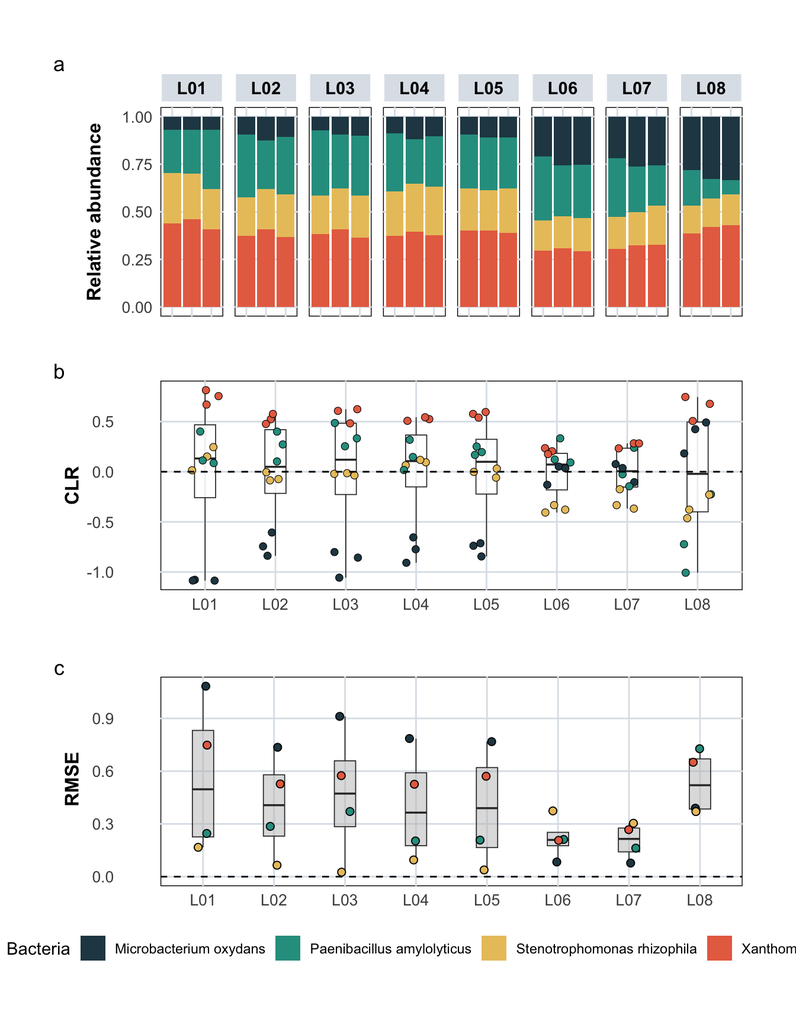

```r
custom_ggplot_theme_mock <- custom_ggplot_theme +
  theme(plot.margin = unit(c(0, 0, 0, 0), "pt"))

# Composition of the mock community plot
fig_s1_1_a <- tidy_plot_genome_counts_filt_30_mock_closed %>%
  filter(culture == "MX") %>%
  ggplot(aes(x = microsample, y = count, fill = species, group = species)) +
  geom_col(position = "fill") +
  scale_fill_manual(values = c("#264653", "#2A9D8F", "#E9C46A", "#E76F51")) +
  labs(x = NULL, y = "Relative abundance", fill = "Bacteria") +
  facet_nested(. ~ buffer, scales = "free", space = "free", switch = "y") +
  theme_minimal() +
  custom_ggplot_theme +
  theme(axis.text.x = element_blank()) +
  theme(legend.position = "bottom") +
  theme(panel.spacing = unit(0.5, "lines"))

# CLR values (relative abundance) of each taxon vs expected relative abundance (CLR=0)
fig_s1_1_b <- mock_wide_CLR_tidy %>%
  ggplot(aes(x = buffer, y = relabun)) +
  geom_boxplot(
    width = 0.3, alpha = 0.5, size = 0.3,
    outlier.shape = NA, position = position_dodge(width = 0.9)
  ) +
  geom_jitter(aes(fill = genome, group = buffer),
    size = 2, alpha = 1.0, shape = 21,
    color = "black",
    stroke = 0.3,
    position = position_jitterdodge(jitter.width = 0.6, dodge.width = 0.9)
  ) +
  scale_fill_manual(values = c("#264653", "#2A9D8F", "#E9C46A", "#E76F51")) +
  labs(x = NULL, y = "CLR") +
  geom_hline(yintercept = 0, linetype = "dashed", color = "black", label = "expected error", linewidth = 0.5) +
  theme_minimal() +
  custom_ggplot_theme_mock +
  theme(legend.position = "none") +
  guides(fill = "none")

# RMSE of CLR relative abundance vs expected CLR
fig_s1_1_c <- ggplot(mock_RMSE_df, aes(x = buffer, y = RMSE)) + # y = mean_RMSE
  geom_boxplot(
    width = 0.3, size = 0.3,
    outlier.shape = NA, fill = "grey", alpha = 0.5
  ) +
  geom_jitter(aes(fill = genome),
    size = 2,
    shape = 21,
    color = "black",
    stroke = 0.5,
    width = 0.1, alpha = 1.0
  ) +
  scale_fill_manual(values = c("#264653", "#2A9D8F", "#E9C46A", "#E76F51")) +
  labs(x = NULL, y = " RMSE") +
  # scale_y_continuous(
  #   limits = c(-0, 10),
  #   breaks = seq(0, 10, by = 0.1)) +
  geom_hline(yintercept = 0, linetype = "dashed", color = "black", label = "expected error", linewidth = 0.5) +
  theme_minimal() +
  custom_ggplot_theme +
  theme(legend.position = "none") +
  guides(fill = "none")

# Combined plot
fig_s1_1 <- fig_s1_1_a / fig_s1_1_b / fig_s1_1_c +
  plot_annotation(tag_levels = 'a') +
  plot_layout(guides = "collect") &
  theme(legend.position = "bottom", legend.box = "vertical")

fig_s1_1
```

#### 3.2.1.2 Microsamples (caecum and colon)

```r
s1_microsample_df <- macroquant_metrics_filt_30 %>%
  filter(
    batch %in% c("MSEB0006", "MSEB0010"), # Caeucum (MSEB0006) and Colon (MSEB0010)
    section %in% c("Caecum right", "Colon"),
    cycles %in% c(13, 14, 15),
    type %in% c("positive"),
    richness > 0
  ) %>%
  mutate(
    collection_attempts = as.factor(collection_attempts),
    buffer = as.factor(buffer)
  )
```

##### 3.2.1.2.1 Sequencing Performance (Fig. S1.2)

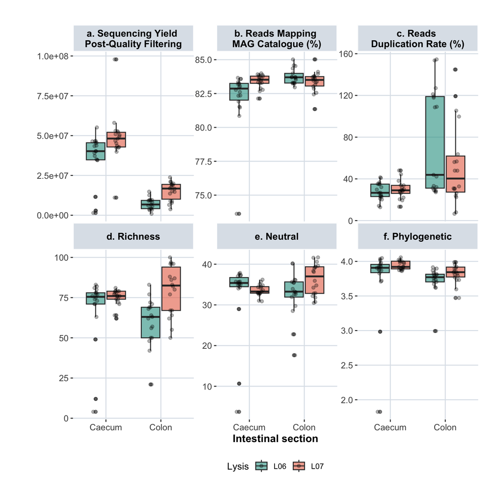

```r
# something wrong duplication rate
ordered_metrics <- c(
  "total_after_filtering.total_reads",
  "mapmag_prokreads_pct",
  "duplication.rate",
  "richness",
  "neutral",
  "phylogenetic"
)

fig_s1_2 <- s1_microsample_df %>%
  mutate(
    mapmag_prokreads_pct = mapmag_prokreads_pct * 100 ) %>%
  pivot_longer(
    cols = -c(names(mssm_sample_metadata), "cov_filtering"),
    names_to = "metric",
    values_to = "value"
  ) %>%
  filter(metric %in% ordered_metrics) %>%
  mutate(
    metric = factor(metric, levels = ordered_metrics),
    metric = fct_recode(metric,
      "a. Sequencing Yield \nPost-Quality Filtering" = "total_after_filtering.total_reads",
      "b. Reads Mapping \nMAG Catalogue (%)" = "mapmag_prokreads_pct",
      "c. Reads \nDuplication Rate (%)" = "duplication.rate",
      "d. Richness" = "richness",
      "e. Neutral" = "neutral",
      "f. Phylogenetic" = "phylogenetic"
    ),
    section = recode(section,
      "Caecum right" = "Caecum",
      "Colon" = "Colon"
    )
  ) %>%
  ggplot(aes(x = section, y = value, fill = buffer)) +
  geom_boxplot(alpha = 0.6) +
  facet_wrap(~metric, scales = "free_y", ncol = 3) +
  labs(
    fill = "Lysis",
    y = "",
    x = "Intestinal section"
  ) +
  # geom_violin(trim = TRUE, alpha = 0.7, position = position_dodge(0.8), na.rm = TRUE) +  # Violin plot
  geom_jitter(
    position = position_jitterdodge(jitter.width = 0.2, dodge.width = 0.8),
    size = 1.5, alpha = 0.3
  ) +
  scale_fill_manual(values = c("#2A9D8F", "#E76F51")) +
  custom_ggplot_theme +
  theme(legend.position = "bottom")

fig_s1_2
```

No clear performance advantage was observed between methods L06 and L07 in caecum microsamples. Although L06 was initially selected, a subsequent experiment suggested that L07 may offer enhanced lysis performance in colon microsamples.

**Note:** The fit_and_analyze_model(), format_anova() and run_metric() function needs to be loaded.

```r
s1_stat <- s1_microsample_df %>%
  group_by(section, buffer) %>%
  summarise(
    `a. Sequencing Yield Post-Quality Filtering` = format_median_iqr(total_after_filtering.total_reads / 1000000),
    `b. Reads Mapping MAG Catalogue (%)`   = format_median_iqr(mapmag_prokreads_pct),
    `d. Richness`     = format_median_iqr(richness),
    `e. Neutral`       = format_median_iqr(neutral),
    `f. Phylogenetic`  = format_median_iqr(phylogenetic),
    .groups = "drop"
  ) %>%
  as.data.frame()

knitr::kable(
  s1_stat,
  booktabs = TRUE,
  align = "lccc",
  caption = "Median percentage (IQR)"
)
```

(#tab:s1micro_stat)Median percentage (IQR)

| section | buffer | a. Sequencing Yield Post-Quality Filtering | b. Reads Mapping MAG Catalogue (%) | d. Richness | e. Neutral | f. Phylogenetic |
| --- | --- | --- | --- | --- | --- | --- |
| Caecum right | L06 | 40.2 (34.8–45.5) | 0.8 (0.8–0.8) | 75.5 (71.0–78.0) | 35.4 (34.5–36.7) | 3.9 (3.8–4.0) |
| Caecum right | L07 | 48.2 (42.9–52.1) | 0.8 (0.8–0.8) | 76.0 (74.0–79.0) | 33.3 (32.9–34.5) | 3.9 (3.9–4.0) |
| Colon | L06 | 6.7 (4.1–9.3) | 0.8 (0.8–0.8) | 63.0 (50.0–69.0) | 33.3 (31.9–35.6) | 3.8 (3.7–3.8) |
| Colon | L07 | 16.8 (10.1–19.4) | 0.8 (0.8–0.8) | 82.5 (67.0–94.0) | 37.0 (32.8–39.4) | 3.8 (3.8–3.9) |

```r
# missing duplication rate!
metrics <- tibble::tribble(
  ~metric,           ~response_var,                       ~model, ~distribution,
  "Reads retained",  "total_after_filtering.total_reads", "glm",  "quasipoisson",
  "MAG mapping (%)", "mapmag_prokreads_pct",              "glm",  "quasibinomial",
  "Richness",        "richness",                          "glm",  "quasipoisson",
  "Neutral",         "neutral",                           "lm",   NA_character_,
  "Phylogenetic",    "phylogenetic",                      "lm",   NA_character_
)
sections <- c("Caecum right", "Colon")
s1micro_test <-
  tidyr::crossing(metrics, section_name = sections) %>%
  purrr::pmap_dfr(
    run_metric,
    explanatory_var = "collection_attempts + buffer",
    term_name = "buffer",
    data = s1_microsample_df
  ) %>%
  select(metric, section_name, report)
s1micro_test
```

```
# A tibble: 10 × 3
   metric          section_name report
   <chr>           <chr>        <chr>
 1 MAG mapping (%) Caecum right <NA>
 2 MAG mapping (%) Colon        <NA>
 3 Neutral         Caecum right <NA>
 4 Neutral         Colon        <NA>
 5 Phylogenetic    Caecum right <NA>
 6 Phylogenetic    Colon        <NA>
 7 Reads retained  Caecum right <NA>
 8 Reads retained  Colon        <NA>
 9 Richness        Caecum right <NA>
10 Richness        Colon        <NA>
```

##### 3.2.1.2.3 Taxa Overlap

**Note:** The pivot_phylo() and compare_taxa_overlap() function needs to be loaded.

[figure not shown]

```r
s1micro_phylo_lg <- pivot_phylo(
  phyloseq_obj = subset_samples(
    physeq_all,
    type == "positive" & section == "Colon" &
      batch == "MSEB0010" & cycles %in% c(13, 14, 15) &
      richness > 0
  ),
  glom = TRUE,
  tax_transform = TRUE,
  taxon_level = "genus",
  tr_method = "compositional" # remove this
) %>% filter(abundance > 0)

s1micro_taxa <- compare_taxa_overlap(
  data = s1micro_phylo_lg,
  group_var = "buffer",
  group_a = "L06",
  group_b = "L07",
  taxon_var = "genus",
  abundance_var = "abundance",
  sample_var = "microsample"
)

s1micro_taxa_plot <- ggplot(s1micro_taxa$plot_df,
       aes(x = prevalence,
           y = mean_abundance,
           color = Detection)) +
  geom_point(size = 3, alpha = 0.85)   +
  scale_color_manual(
    values = c(
      "L06" = "#2A9D8F",
      "L07" = "#E76F51",
      "Shared" = "grey80"
    )
  ) +
  scale_y_log10(labels = scales::label_scientific()) +
  scale_x_continuous(labels = scales::percent_format()) +
  labs(
    x = "Prevalence in microsample",
    y = "Mean relative abundance (log scale)"
    ) +
  pnas_theme + theme(legend.position = "bottom")
sn1_taxa_plot
```

## 3.3 S2: Resource optimisation

```r
s2_df <- macroquant_metrics_filt_30 %>%
  filter(
    batch %in% c("MSEB0009", "MSEB0014", "MSEB0015"),
    type %in% c("positive"),
    size %in% c("5000"),
    !between(as.numeric(sub("M", "", microsample)), 300651, 300665)
  ) %>%
  mutate(
    protocol = ifelse(protocol %in% c("ULV2_Full"), "100%", "50%"),
    comparison = ifelse(batch %in% c("MSEB0009"), "Cost", "Throughput"),
    lib_method = ifelse(batch %in% c("MSEB0015"), "Automation (1 plate set-up)", "Manual"),
    comparison_grid = ifelse(comparison == "Cost", protocol, lib_method)
  ) %>%
  mutate(
    comparison = as.factor(comparison),
    comparison_grid = as.factor(comparison_grid)
  ) # %>% count(comparison, batch)
```

### 3.3.1 Summary Statistic

```r
s2_stat <- s2_df %>%
  mutate(
    other = total_before_filtering.total_reads -
      (
        (total_before_filtering.total_reads - total_after_filtering.total_reads) +
        reads_mapped_chicken +
        reads_mapped_human +
        reads_mapped_pig +
        reads_mapped_mag +
        reads_unmapped_mag
      ),
    low_quality_reads = total_before_filtering.total_reads - total_after_filtering.total_reads
  ) %>%
  select(
    microsample,
    comparison_grid,
    total_before_filtering.total_reads,
    low_quality_reads,
    reads_mapped_chicken,
    reads_mapped_human,
    reads_mapped_pig,
    reads_mapped_mag,
    reads_unmapped_mag,
    other
  ) %>%
  mutate(
    across(
      -c(microsample, comparison_grid, total_before_filtering.total_reads),
      ~ (. / total_before_filtering.total_reads) * 100,
      .names = "{.col}_pct"
    )
  ) %>%
  select(microsample, comparison_grid, ends_with("_pct")) %>%
  group_by(comparison_grid) %>%
  summarise(
    low_quality_reads = format_median_iqr(low_quality_reads_pct),
    mapping_chicken   = format_median_iqr(reads_mapped_chicken_pct),
    mapping_human     = format_median_iqr(reads_mapped_human_pct),
    mapping_pig       = format_median_iqr(reads_mapped_pig_pct),
    mapping_bacteria  = format_median_iqr(reads_mapped_mag_pct),
    unmapped_bacteria = format_median_iqr(reads_unmapped_mag_pct),
    other             = format_median_iqr(other_pct),
    .groups = "drop"
  ) %>%
  tibble::column_to_rownames("comparison_grid") %>%
  t() %>%
  as.data.frame()

knitr::kable(
  s2_stat,
  booktabs = TRUE,
  align = "lccc",
  caption = "Median percentage (IQR) of reads in each processing category"
)
```

(#tab:s2_stat)Median percentage (IQR) of reads in each processing category

|  | 100% | 50% | Automation (1 plate set-up) | Manual |
| --- | --- | --- | --- | --- |
| low_quality_reads | 12.0 (6.1–30.4) | 3.3 (2.9–3.8) | 2.6 (2.3–3.0) | 3.5 (3.3–3.7) |
| mapping_chicken | 0.0 (0.0–0.1) | 0.0 (0.0–0.0) | 0.0 (0.0–0.1) | 0.0 (0.0–0.1) |
| mapping_human | 0.0 (0.0–0.0) | 0.0 (0.0–0.0) | 1.4 (1.0–2.0) | 1.2 (0.8–1.9) |
| mapping_pig | 0.0 (0.0–0.0) | 0.0 (0.0–0.0) | 0.0 (0.0–0.0) | 0.0 (0.0–0.0) |
| mapping_bacteria | 72.4 (58.0–78.2) | 80.4 (79.8–80.8) | 78.8 (77.1–79.7) | 78.6 (77.3–79.0) |
| unmapped_bacteria | 15.2 (11.6–15.7) | 16.2 (16.0–16.5) | 17.0 (16.6–17.6) | 16.6 (16.1–16.9) |
| other | 0.0 (0.0–0.0) | 0.0 (0.0–0.0) | 0.0 (0.0–0.0) | 0.0 (0.0–0.0) |

### 3.3.2 Sequencing Performance (Fig. S2.1a)

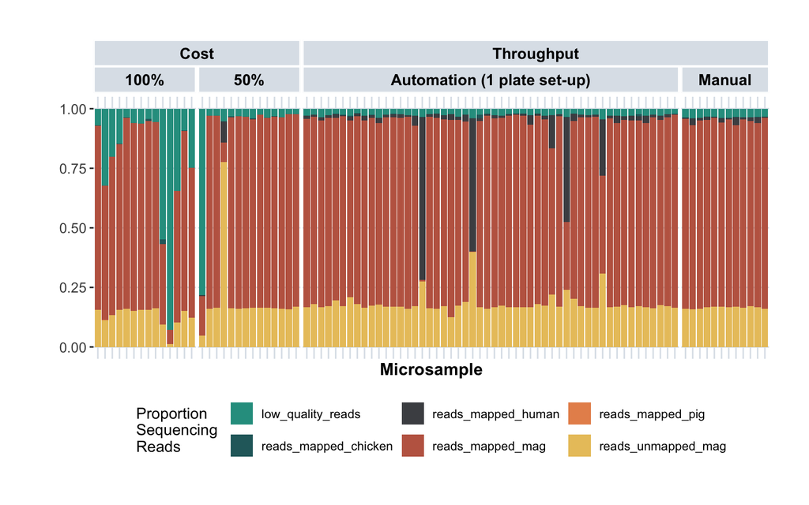

```r
ordered_metrics <- c(
  # "total_before_filtering.total_reads",
  "low_quality_reads",
  "reads_mapped_chicken",
  "reads_mapped_human",
  "reads_mapped_pig",
  "reads_mapped_mag",
  "reads_unmapped_mag",
  "reads_other"
)

fig_s2_1a <- s2_df %>%
  mutate(
    other = total_before_filtering.total_reads - ((total_before_filtering.total_reads - total_after_filtering.total_reads)
    + reads_mapped_chicken + reads_mapped_human + reads_mapped_pig + reads_mapped_mag + reads_unmapped_mag),
    low_quality_reads = total_before_filtering.total_reads - total_after_filtering.total_reads
  ) %>%
  pivot_longer(
    cols = -c(names(mssm_sample_metadata), comparison, lib_method, comparison_grid, cov_filtering),
    names_to = "metric",
    values_to = "value"
  ) %>%
  filter(metric %in% ordered_metrics) %>%
  mutate(microsample = as.factor(microsample)) %>%
  ggplot(aes(x = microsample, y = value, fill = metric)) +
  geom_bar(position = "fill", stat = "identity") +
  scale_fill_manual(values = c(colorRampPalette(supplementary_color)(6))) +
  labs(x = "Microsample", y = "", fill = "Read type") +
  facet_nested(. ~ comparison + comparison_grid, scales = "free", space = "free", switch = "y") +
  theme(axis.text.x = element_text(angle = 90, hjust = 1)) +
  custom_ggplot_theme +
  theme(axis.text.x = element_blank(), axis.ticks.x = element_blank()) +
  theme(legend.position = "bottom") +
  guides(fill = guide_legend(title = "Proportion \nSequencing \nReads"))
fig_s2_1a
```

### 3.3.3 Library Preparation Efficiency (Fig. S2.1b)

```r
s2_dreamprep_df <- read_tsv("resources/zenodo/sn3_5_dreamprep_df.tsv", show_col_types = FALSE)
s2_dreamprep_df <- s2_dreamprep_df %>%
  mutate(plate = str_extract(sample, "^Plate \\d+")) %>%
  filter(
    !Range %in% c("35 bp to 100 bp"),
    concentration %in% c("0.1"),
    type %in% c("Positive")
  ) %>%
  mutate(
    # Range = droplevels(Range),
    plate = case_when(
      grepl("Plate 1", plate, ignore.case = TRUE) ~ "Single-Plate",
      grepl("Plate 2", plate, ignore.case = TRUE) ~ "Dual-Plate A",
      grepl("Plate 3", plate, ignore.case = TRUE) ~ "Dual-Plate B",
      TRUE ~ NA_character_
    ),
    plate = factor(plate, levels = c("Single-Plate", "Dual-Plate A", "Dual-Plate B")),
    concentration = paste0("DNA Input ", concentration, " ng/μL"),
    Range = case_when(
      grepl("100 bp to 200 bp", Range, ignore.case = TRUE) ~ "Non-specific Short Fragments",
      grepl("200 bp to 1000 bp", Range, ignore.case = TRUE) ~ "Library",
      TRUE ~ NA_character_
    )
  )
```

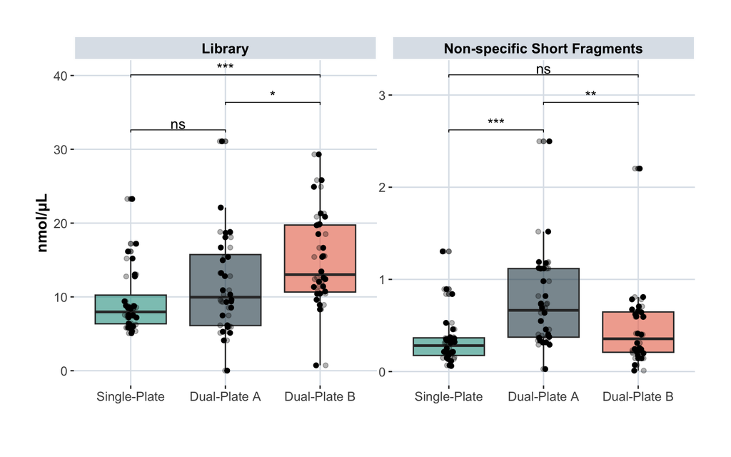

```r
comparisons <- list(c("Single-Plate", "Dual-Plate A"), c("Dual-Plate A", "Dual-Plate B"), c("Single-Plate", "Dual-Plate B"))
fig_s2_1b <- s2_dreamprep_df %>%
  ggplot(aes(x = plate, y = nmole_L, fill = plate)) +
  geom_boxplot(position = position_dodge(width = 0.75), alpha = 0.6) +
  geom_point(position = position_jitterdodge(0.2)) +
  stat_compare_means(
    comparisons = comparisons,
    method = "wilcox.test",
    label = "p.signif",
    p.adjust.method = "BH",
    size = 4,
    vjust = 0.2,
    tip.length = 0.01
  ) +
  # scale_y_continuous(trans="log10") +
  facet_wrap(~Range, scales = "free") +
  labs(
    y = "nmol/μL",
    x = "",
  ) +
  geom_jitter(
    position = position_jitterdodge(jitter.width = 0.2, dodge.width = 0.8),
    size = 1.5, alpha = 0.3
  ) +
  scale_fill_manual(values = c("#2A9D8F", "#264653", "#E76F51")) +
  custom_ggplot_theme +
  theme(legend.position = "none")
fig_s2_1b
```

## 3.4 Design Considerations: Microsample Area

```r
custom_ggplot_theme_LMD_size <- custom_ggplot_theme +
  theme(
        legend.text = element_text(size = 7),
        legend.title = element_text(size = 7),
        axis.text = element_text(size = 5),
        axis.title = element_text(size = 7, face = "bold"),
        strip.text = element_text(size = 7, face = "bold", color = "black"),
        plot.title = element_text(size = 7, face = "bold", color = "black"),
        plot.margin = unit(c(0, 0, 0, 0), "cm"))

size_colors <- c("500" = '#ffdf9e', "1500" = '#ffc273', "2500" = '#e56969', "5000" = '#c1558b', "25000" = '#8a49a1',"50000" = '#4f5bd5')

# Make a-diversity df tidy for plotting
macroquant_metrics_filt_30_tidy <- macroquant_metrics_filt_30 %>%
  pivot_longer(
    cols = c(richness, neutral, phylogenetic),
    names_to = "metric",
    values_to = "value") %>%
  mutate(metric = factor(metric, levels = c("richness", "neutral", "phylogenetic")),
         size = factor(size, levels = c(500, 1500, 2500, 5000, 25000, 50000)))
```

### 3.4.1 Fig. 2b

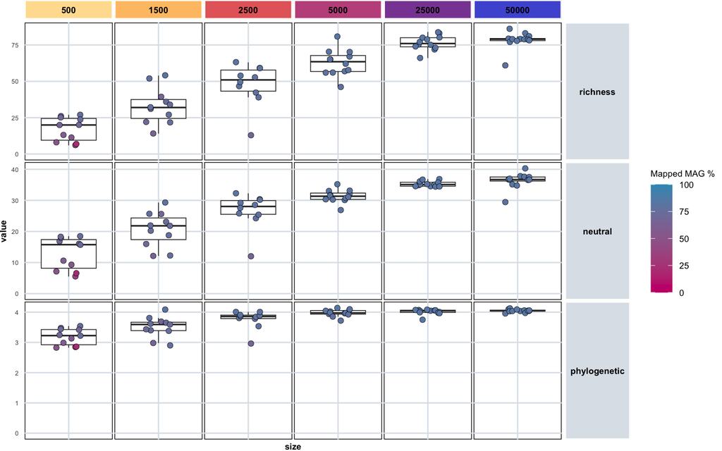

```r
# Plot a-diversity metrics for different microsample sizes
fig2b <- macroquant_metrics_filt_30_tidy %>%
  filter(batch == "MSEB0014") %>%
  filter(value > 1) %>% # to filter the samples with richness = 0, i.e. expShannon = 1
  filter(type == "positive") %>%
  ggplot(aes(x = size, y = value, fill = mapmag_filteredreads_pct*100)) +
    geom_boxplot(outlier.shape = NA, size = 0.3) +
    geom_jitter(shape = 21, color = "black",
                width = 0.2, alpha = 1,
                size = 2, stroke = 0.2) +
    scale_fill_gradient(low = "#c90076", high = "#3598bf",
                         name = "Mapped MAG %", limits = c(0, 100)) +
    facet_nested(metric ~ size, scales = "free", space = "fixed",
                 strip = strip_themed(
                  background_x = elem_list_rect(
                  fill = size_colors,
                  colour = "white",
                  size = 0.8))) +
    ylim(0, NA) +
    theme_minimal() +
    custom_ggplot_theme_LMD_size +
    theme(axis.text.x = element_blank())
fig2b
```

```r
# mapmag_prokreads_pct
# mapmag_filteredreads_pct
```

```r
# Mapped MAG median
macroquant_metrics_filt_30_tidy %>%
  filter(batch == "MSEB0014") %>%
  filter(metric == "richness") %>%
  filter(value > 1) %>%  # remove richness = 0 samples
  filter(type == "positive") %>%
  group_by(size) %>%
  summarise(
    median_pct = median(mapmag_filteredreads_pct * 100, na.rm = TRUE),
    IQR_pct    = IQR(mapmag_filteredreads_pct * 100, na.rm = TRUE),
    host_median_pct = median(host_pct * 100, na.rm = TRUE),
    host_IQR_pct    = IQR(host_pct * 100, na.rm = TRUE),
    human_median_pct = median(human_pct * 100, na.rm = TRUE),
    human_IQR_pct    = IQR(human_pct * 100, na.rm = TRUE),
    bac_median_pct = median(mapmag_prokreads_pct * 100, na.rm = TRUE),
    bac_IQR_pct    = IQR(mapmag_prokreads_pct * 100, na.rm = TRUE),
    .groups = "drop"
  ) %>%
  knitr::kable()
```

| size | median_pct | IQR_pct | host_median_pct | host_IQR_pct | human_median_pct | human_IQR_pct | bac_median_pct | bac_IQR_pct |
| --- | --- | --- | --- | --- | --- | --- | --- | --- |
| 500 | 65.89115 | 16.3941394 | 0.0363361 | 0.0876485 | 11.3995077 | 11.9075556 | 74.59894 | 8.5131286 |
| 1500 | 75.36138 | 4.3270866 | 0.0330689 | 0.1282388 | 5.0313752 | 2.3162392 | 79.52355 | 1.5521432 |
| 2500 | 79.20876 | 1.6844339 | 0.0384782 | 0.0721877 | 2.0392975 | 1.1377266 | 81.49651 | 0.6131339 |
| 5000 | 81.50319 | 1.5955203 | 0.0320767 | 0.0657973 | 1.2428064 | 1.1148923 | 82.47704 | 0.7501770 |
| 25000 | 82.65133 | 0.4600388 | 0.0351382 | 0.0486685 | 0.2665449 | 0.2191347 | 82.95911 | 0.3331923 |
| 50000 | 82.96293 | 0.4584162 | 0.0446544 | 0.1153114 | 0.1301753 | 0.0764656 | 83.20100 | 0.3900367 |

### 3.4.2 Fig. 2c

```r
# Select data for PCA and make wide df
LMD_size_df_wide <- macroquant_genome_counts_filt_30_tidy %>%
  filter(batch == "MSEB0014") %>%
  filter(type == "positive") %>%
  select(genome, microsample, count,) %>% #  size
  pivot_wider(names_from = genome,values_from = count,values_fill = 0) %>%
  select(where(~ any(. != 0)) | where(is.character) | where(is.factor)) %>%
  mutate(across(-c(microsample), ~ . / rowSums(across(where(is.numeric))) * 100 )) %>%
  column_to_rownames(var = "microsample")

# 68 obs x 88 variables

# Remove samples with few taxa and taxa in few samples
LMD_size_df_wide <- remove_samples_or_taxa(df = LMD_size_df_wide,
                                           min_samples_per_taxon = 6,
                                           min_taxa_per_sample = 14)
```

```
Initial df: Rows (samples): 68 , Columns (taxa): 88
Removed: Rows (samples): 7 , Columns (taxa): 9
Resulting df: Rows (samples): 61 , Columns (taxa): 79
```

```r
# 61 obs x 79 variables
# Perform & plot PCA
LMD_size_pca <- perform_pca(LMD_size_df_wide, z_delete = TRUE)
```

```
[1] "Zeros found"
No. adjusted imputations:  129
Rows (samples) removed after zero replacement: 0
Columns (taxa) removed after zero replacement: 0
```

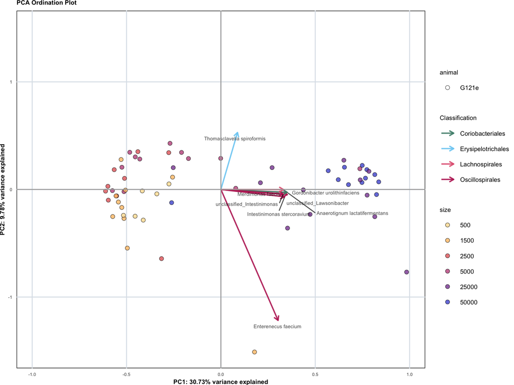

```r
fig2c <- plot_pca(LMD_size_pca$pca_result,
         samples_color_metadata = "size",
         samples_color_value = size_colors,
         samples_shape_metadata = "animal",
         loadings_color_metadata = "order",
         loadings_color_value = order_colors,
         loadings_taxon_level = "species",
         sample_metadata = macroquant_metrics_filt_30,
         genome_metadata = macromag_genomemetadata,
         order_colors= order_colors,
         custom_ggplot_theme = custom_ggplot_theme_LMD_size,
         loadings_number = 8)

fig2c
```

### 3.4.3 Fig. 2d

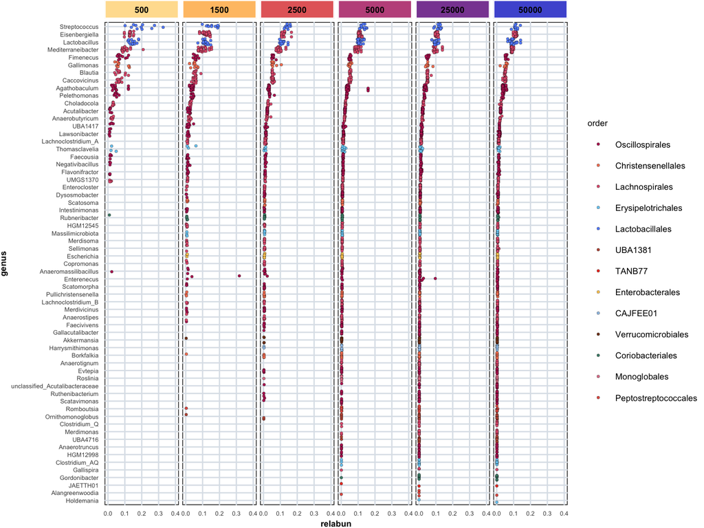

```r
# Relative abundance at genus level
LMD_size_rel_abun <- macroquant_genome_counts_filt_30_tidy %>%
  filter(batch == "MSEB0014") %>%
  filter(type == 'positive') %>%
  group_by(microsample, order, genus) %>%
  mutate(relabun = sum(count)) %>%
  ungroup()
# Plot relative abundance
LMD_size_taxa_sorted <- LMD_size_rel_abun %>%
  group_by(genus) %>%
  summarise(median = median(relabun, na.rm = T)) %>%
  arrange(-median)

# Reorder taxon_level based on the summary
fig2d <- LMD_size_rel_abun %>%
  mutate(genus = factor(genus, levels = rev(LMD_size_taxa_sorted %>% pull(genus))))  %>%
  ggplot(aes(x = relabun, y = genus, group = genus, fill = order)) +
      scale_fill_manual(values = order_colors) +
    geom_jitter(shape = 21, alpha = 1, size=1,
                color = "black", stroke = 0.1) +
    facet_nested(. ~  size,
                 scales = "free", space = "free", switch = "y",
                 strip = strip_themed(
                  background_x = elem_list_rect(
                  fill = size_colors,
                  colour = "white",
                  size = 0.8))) +
    theme_minimal() +
    custom_ggplot_theme_LMD_size +
    scale_x_continuous(limits = c(0, 0.4)) +
    theme(panel.spacing = unit(0.2, "lines"))

fig2d
```

## 3.5 Performance Evaluation Across Intestinal Sections

```r
section_df <- macroquant_metrics_filt_30 %>%
  filter(
    batch %in% c("MSEB0006", "MSEB0010"),
    section %in% c("Caecum right", "Ileum", "Colon"),
    type %in% c("positive"),
    richness > 0
  ) %>%
  mutate(
    collection_attempts = as.factor(collection_attempts),
    buffer = as.factor(buffer),
    cycles = as.factor(cycles)
  )
```

### 3.5.1 Summary Statistic

```r
section_stat <- section_df %>%
  filter(!cycles %in% c("19")) %>%
  group_by(section) %>%
  summarise(
    `a. Low Quality Reads (%)`   = format_median_iqr(lowquality_reads_pct*100),
    `b. Reads Mapping Eukaryotic Host (%)`     = format_median_iqr(host_pct*100),
    `c. Reads Mapping MAG Catalogue (%)`       = format_median_iqr(mapmag_prokreads_pct*100),
    `d. Microbial Fraction  Based On SCG (%)`  = format_median_iqr(read_fraction_singlem*100),
    `e. Richness`  = format_median_iqr(richness),
    .groups = "drop"
  ) %>% t() %>%
  as.data.frame()

knitr::kable(
  section_stat,
  booktabs = TRUE,
  align = "lccc",
  caption = "Median percentage (IQR)"
)
```

(#tab:section_stat)Median percentage (IQR)

|  | V1 | V2 | V3 |
| --- | --- | --- | --- |
| section | Caecum right | Colon | Ileum |
| a. Low Quality Reads (%) | 4.2 (3.3–5.3) | 47.5 (14.0–72.6) | 23.6 (8.9–50.3) |
| b. Reads Mapping Eukaryotic Host (%) | 0.0 (0.0–0.0) | 0.0 (0.0–0.0) | 3.4 (0.4–14.6) |
| c. Reads Mapping MAG Catalogue (%) | 83.3 (82.6–83.6) | 83.6 (83.3–83.8) | 63.0 (48.4–74.2) |
| d. Microbial Fraction Based On SCG (%) | 73.7 (72.6–75.7) | 74.1 (71.7–75.0) | 67.8 (53.2–92.5) |
| e. Richness | 76.0 (71.5–78.5) | 69.0 (59.5–83.0) | 3.0 (2.0–3.2) |

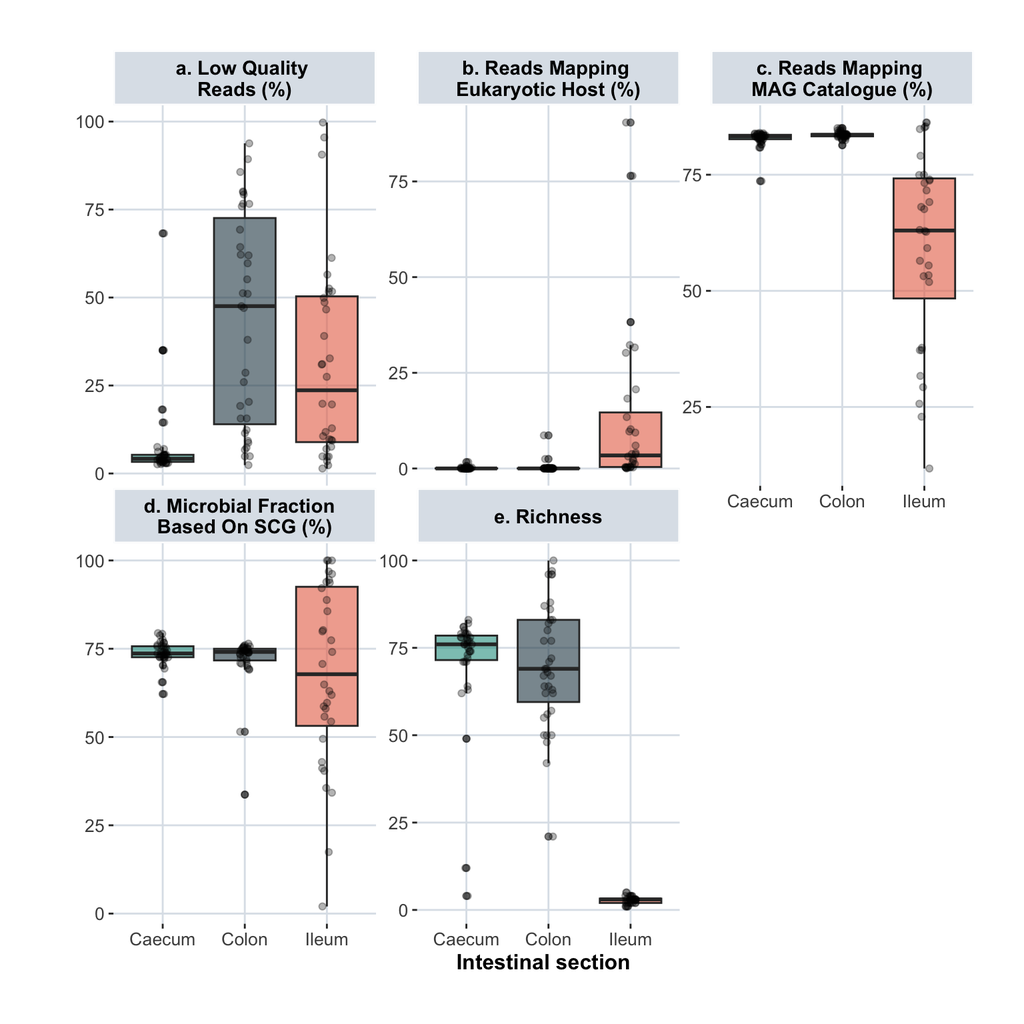

```r
ordered_metrics <- c(
  "lowquality_reads_pct",
  "host_pct",
  "mapmag_prokreads_pct",
  "read_fraction_singlem",
  "richness"
)

boxplot_section_comparison <- section_df %>%
  filter(!cycles %in% c("19")) %>%
  mutate(
    lowquality_reads_pct = lowquality_reads_pct * 100,
    host_pct = host_pct * 100,
    mapmag_prokreads_pct = mapmag_prokreads_pct * 100,
    read_fraction_singlem = read_fraction_singlem * 100
  ) %>%
  pivot_longer(
    cols = -c(names(mssm_sample_metadata), "cov_filtering"),
    names_to = "metric",
    values_to = "value"
  ) %>%
  filter(metric %in% ordered_metrics) %>%
  mutate(
    metric = factor(metric, levels = ordered_metrics),
    metric = fct_recode(metric,
      "a. Low Quality \nReads (%)" = "lowquality_reads_pct",
      "b. Reads Mapping \nEukaryotic Host (%)" = "host_pct",
      "c. Reads Mapping \nMAG Catalogue (%)" = "mapmag_prokreads_pct",
      "d. Microbial Fraction  \nBased On SCG (%)" = "read_fraction_singlem",
      "e. Richness" = "richness"
    ),
    section = recode(section,
      "Caecum right" = "Caecum",
      "Colon" = "Colon"
    )
  ) %>%
  ggplot(aes(x = section, y = value, fill = section)) +
  geom_boxplot(alpha = 0.6) +
  facet_wrap(~metric, scales = "free_y", ncol = 3) +
  labs(
    fill = "",
    y = "",
    x = "Intestinal section"
  ) +
  # geom_violin(trim = TRUE, alpha = 0.7, position = position_dodge(0.8), na.rm = TRUE) +  # Violin plot
  geom_jitter(
    position = position_jitterdodge(jitter.width = 0.2, dodge.width = 0.8),
    size = 1.5, alpha = 0.3
  ) +
  scale_fill_manual(values = c("#2A9D8F", "#264653", "#E76F51")) +
  custom_ggplot_theme +
  theme(legend.position = "none")

boxplot_section_comparison
```

Library-building performance, evaluated using sequencing and diversity metrics, was highest in the caecum, lower in the colon, and poorest in the ileum.

**Note:** The fit_and_analyze_model(), format_anova() and run_metric() function needs to be loaded.

```r
metrics <- tibble::tribble(
  ~metric,                         ~response_var,                    ~model, ~distribution,
  "Low quality reads (%)",        "lowquality_reads_pct",          "glm", "quasibinomial",
  "Host mapping (%)",             "host_pct",                      "glm", "quasibinomial",
  "MAG mapping (%)",              "mapmag_prokreads_pct",         "glm", "quasibinomial",
  "Single-copy gene fraction (%)","read_fraction_singlem",        "glm", "quasibinomial",
  "Richness",           "richness",                            "glm",  "quasipoisson"

)

section_test <- metrics %>%
  purrr::pmap_dfr(function(metric, response_var, model, distribution) {
    run_metric(
      metric = metric,
      response_var = response_var,
      model = model,
      distribution = distribution,
      explanatory_var = "collection_attempts + section",
      term_name = "section",
      data = section_df %>%
            filter(!cycles %in% c("19"))
    )
  }) %>%
  select(metric, report)
section_test
```

```
# A tibble: 5 × 2
  metric                        report
  <chr>                         <chr>
1 Low quality reads (%)         <NA>
2 Host mapping (%)              <NA>
3 MAG mapping (%)               <NA>
4 Single-copy gene fraction (%) <NA>
5 Richness                      <NA>
```

```r
cat("Correlation", "\n")
```

```
Correlation
```

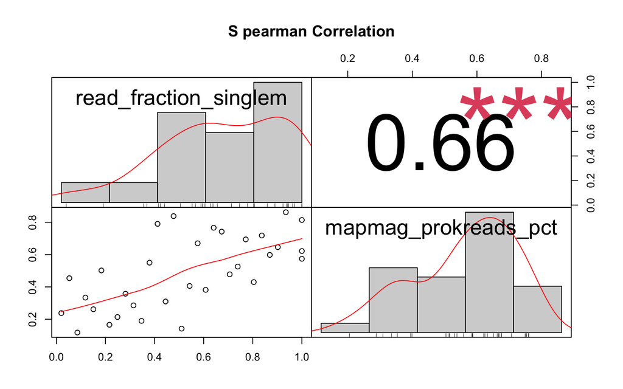

```r
chart.Correlation(section_df %>%
  filter(section %in% c("Ileum")) %>%
  select(
    "read_fraction_singlem",
    "mapmag_prokreads_pct"
  ), method = "spearman")
```

Single-copy gene analysis showed a moderate correlation with the proportion of reads mapping to the reference post-filtering.

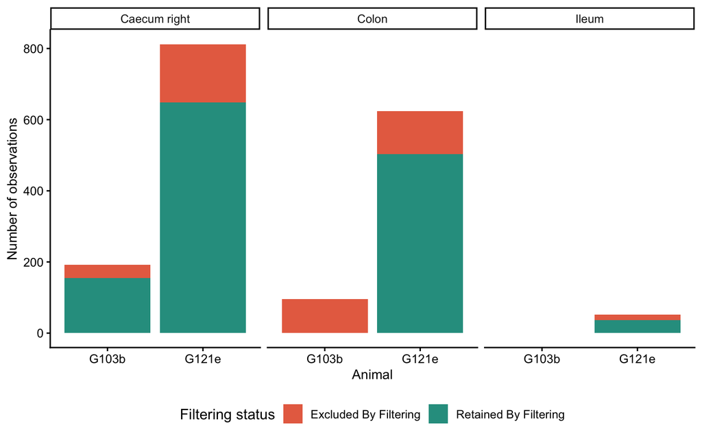

```r
animal_section_df <- macroquant_metrics_filt_30 %>%
  filter(
    section %in% c("Caecum right", "Colon", "Ileum")
  ) %>%
  group_by(animal, section, cov_filtering) %>%
  summarise(
    count = n(),
    .groups = "drop"
  )
ggplot(animal_cov_plot_df,
       aes(x = animal,
           y = count,
           fill = cov_filtering)) +
  geom_col(position = "stack") +
  facet_wrap(~section) +
  scale_fill_manual(
    values = c(
      "Retained By Filtering" = "#2A9D8F",
      "Excluded By Filtering" = "#E76F51"
    )
  ) +
  labs(
    x = "Animal",
    y = "Number of observations",
    fill = "Filtering status"
  ) +
  pnas_theme +
  theme(legend.position = "bottom")
```

MSSM performance at 5,000 μm² in the caecum of a 35-day-old (G121e) animal matched that of a 14-day-old (G103b) individual. Colon samples from the 14-day-old animal performed poorlydue to insufficient genome coverage.

### 3.5.3 Confocal Microscopy Of DAPI-stained Microsections (Fig. S5a)

```r
dapi <- dapi_df %>%
  group_by(Animal, Sequence, Age, Section) %>%
  summarise(
    n = n(),
    Distance_from_one_side_mn = mean(Distance_from_one_side, na.rm = TRUE),
    Distance_from_one_side_sd = ifelse(n > 1, sd(Distance_from_one_side), NA_real_),
    mean = mean(Bacterial_count),
    median = median(Bacterial_count),
    sd_na = ifelse(n > 1, sd(Bacterial_count), NA_real_), # If only 1 obs, return NA
    sd = ifelse(n() > 1, sd(Bacterial_count, na.rm = TRUE), 0), # Avoid NA SD
    sem = ifelse(n > 1, sd / sqrt(n), 0), # Set SEM to 0 if only 1 observation
    q1 = quantile(Bacterial_count, 0.25), # First quartile
    q3 = quantile(Bacterial_count, 0.75), # Third quartile
    .groups = "drop"
  )

summary <- dapi_df %>%
  group_by(Age, Section) %>%
  summarise(
    n = n(),
    mean = mean(Bacterial_count),
    median = median(Bacterial_count),
    sd_na = ifelse(n > 1, sd(Bacterial_count), NA_real_), # If only 1 obs, return NA
    sd = ifelse(n() > 1, sd(Bacterial_count, na.rm = TRUE), 0), # Avoid NA SD
    q1 = quantile(Bacterial_count, 0.25), # First quartile
    q3 = quantile(Bacterial_count, 0.75), # Third quartile
    .groups = "drop"
  )
```

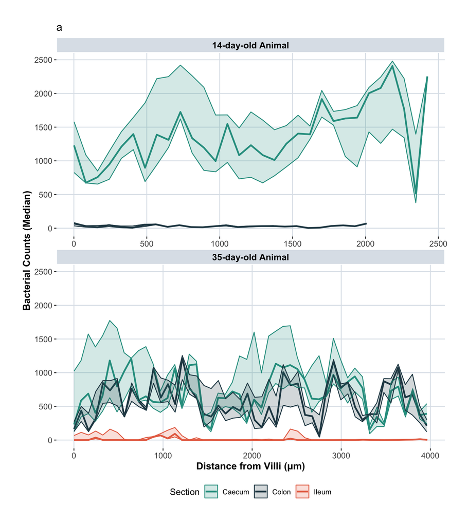

```r
figs5a <- ggplot(dapi, aes(x = Distance_from_one_side_mn, y = median, color = Section)) +
  geom_line(linewidth = 1) + # Mean line
  geom_ribbon(aes(ymin = q1, ymax = q3, fill = Section),
    alpha = 0.2
  ) + # SEM shading
  labs(
    title = "a",
    x = "Distance from Villi (μm)",
    y = "Bacterial Counts (Median)"
  ) +
  facet_wrap(~Age, nrow = 2, scale = "free_x") +
  scale_fill_manual(values = c("#2A9D8F", "#264653", "#E76F51"), drop = FALSE) +
  scale_color_manual(values = c("#2A9D8F", "#264653", "#E76F51"), drop = FALSE) +
  custom_ggplot_theme +
  theme(legend.position = "bottom")
figs5a
```

Quantification of bacterial cells within a 5,000 μm² area using QuPath provides visual confirmation that differences in bacterial density across intestinal regions (caecum, colon, and ileum) were the primary factor influencing MSSM performance.

## 3.6 Microbial Genomic Reference Data

### 3.6.1 Summary Statistics

#### Reference MAG Catalogue

```r
print_median_iqr(macromag_genomemetadata$completeness, "Completeness:")
```

```
Completeness: median = 99.98 IQR = 94.6 - 100
```

```r
print_median_iqr(macromag_genomemetadata$contamination, "Contamination:")
```

```
Contamination: median = 0.23 IQR = 0 - 1.71
```

#### Micro-scale MAG Catalogue

```r
print_median_iqr(micromag_genomemetadata$completeness, "Completeness:")
```

```
Completeness: median = 96.94 IQR = 91.49 - 99.49
```

```r
print_median_iqr(micromag_genomemetadata$contamination, "Contamination:")
```

```
Contamination: median = 0.58 IQR = 0.21 - 1.83
```

### 3.6.2 Macro vs Micro MAGs: Completeness And Abundance (Fig. 3a)

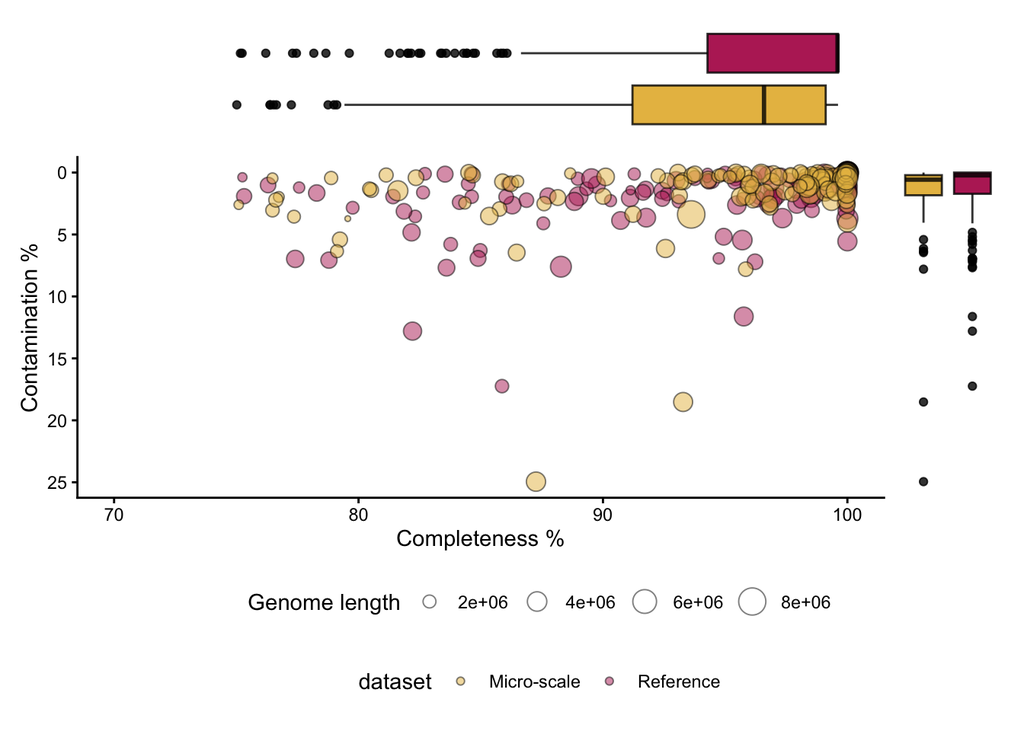

```r
# Load the genome metadata for macro- and micro- MAG catalogues
genome_biplot_data <- macromag_genomemetadata %>%
  select(genome,completeness, contamination, length) %>%
  mutate(dataset = "Reference")

genome_biplot_micro_data <- micromag_genomemetadata %>%
  select(genome, completeness, contamination, length) %>%
  mutate(dataset = "Micro-scale")

# Combine the dfs
combined_data <- bind_rows(genome_biplot_data, genome_biplot_micro_data)

# Plot the combined data
combined_plot <- ggplot(combined_data, aes(x = completeness, y = contamination, size = length, fill = dataset)) +
  scale_fill_manual(values = c("#E8BD50", "#B92D65")) +
  geom_point(shape = 21, color = "black", alpha = 0.5) +
  xlim(c(70, 100)) +
  ylim(c(25, 0)) +
  labs(y = "Contamination %", x = "Completeness %", color = "MAG catalogue", size = "Genome length") +
  theme_classic() +
  theme(legend.position = "none")

# Plot contamination boxplot
genome_contamination <- combined_data %>%
            ggplot(aes(y=contamination, x=dataset, fill=dataset)) +
                    ylim(c(25,0)) +
                    geom_boxplot() +
                    theme_void() +
                    scale_fill_manual(values = c("#E8BD50", "#B92D65")) +
                    guides(fill = "none") +
                    theme(
                        axis.title.x = element_blank(),
                        axis.title.y = element_blank(),
                        axis.text.y=element_blank(),
                        axis.ticks.y=element_blank(),
                        axis.text.x=element_blank(),
                        axis.ticks.x=element_blank(),
                        plot.margin = unit(c(0, 0, 0.40, 0),"inches"))

# Plot completeness boxplot
genome_completeness <- combined_data %>%
        ggplot(aes(x=completeness, y=dataset, fill = dataset)) +
                xlim(c(70,100)) +
                geom_boxplot() +
                theme_void() +
                scale_fill_manual(values = c("#E8BD50", "#B92D65")) +
                guides(fill = "none") +
                theme(
                    axis.title.x = element_blank(),
                    axis.title.y = element_blank(),
                    axis.text.y=element_blank(),
                    axis.ticks.y=element_blank(),
                    axis.text.x=element_blank(),
                    axis.ticks.x=element_blank(),
                    plot.margin = unit(c(0, 0, 0, 0.50),"inches"))

# Align margins
genome_biplot <- combined_plot + theme(plot.margin = margin(5, 5, 5, 5))
genome_completeness <- genome_completeness + theme(plot.margin = margin(0, 5, 0, 5))
genome_contamination <- genome_contamination + theme(plot.margin = margin(5, 0, 5, 0))

# Compose layout
top_row <- genome_completeness + plot_spacer() + plot_layout(widths = c(15, 2))
bottom_row <- genome_biplot + genome_contamination + plot_layout(widths = c(15, 2))
fig3a <- (top_row / bottom_row + plot_layout(heights = c(5, 15))) + plot_layout(guides = "collect") &
  theme(legend.position = "bottom", legend.box = "vertical")

fig3a
```

### 3.6.3 Macro MAGs Overview (Fig. 3b)

```r
fig3b <- MAG_tree_plot(genome_metadata = macromag_genomemetadata, tree = macromag_tree)
```

[output not shown]

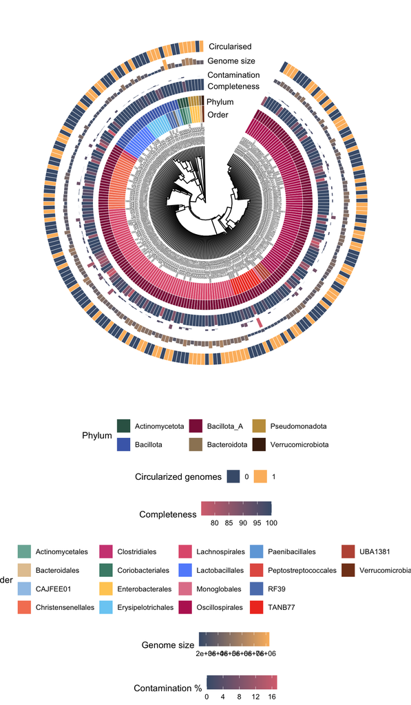

```r
fig3b
```

### 3.6.4 Micro MAGs Overview (Suppl.Fig. 6)

```r
figs1 <- MAG_tree_plot(genome_metadata = micromag_genomemetadata, tree = micromag_tree)
```

[output not shown]

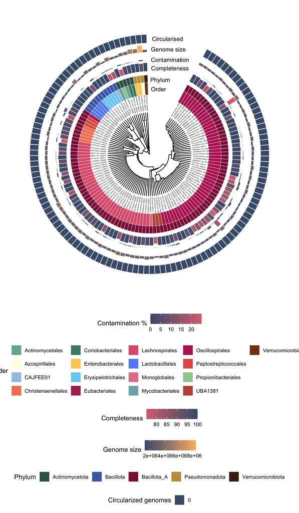

```r
figs1
```

### 3.6.5 Comparative Analysis Of Genome Catalogues

```r
cat("Number Genomes in Reference MAG Catalogue =", length(macromag_taxonomy$genome), "\n")
```

```
Number Genomes in Reference MAG Catalogue = 223
```

```r
cat("Number Genomes in Micro-scale MAG Catalogue =", length(micromag_taxonomy$genome), "\n")
```

```
Number Genomes in Micro-scale MAG Catalogue = 122
```

```r
cat_sample_id <- microquant_metrics_filt_30 %>% # select microquant dataset
  filter(
    batch %in% c("MSEB0011"),
    type %in% c("positive")
  ) %>% pull(microsample)

cat_phylo_count <- full_join(
  microquant_genome_counts_filt_30 %>%
    select(genome, all_of(cat_sample_id))%>%
  filter(rowSums(across(-genome)) != 0) %>%
    rename_with(~ paste0(.x, "_micro"), .cols = -genome),
  macroquant_genome_counts_filt_30 %>%
    select(genome, all_of(cat_sample_id)) %>%
  filter(rowSums(across(-genome)) != 0) %>%
    rename_with(~ paste0(.x, "_macro"), .cols = -genome),
  by = "genome"
) %>%
  mutate(across(
    where(is.numeric),
    ~ replace_na(.x, 0)
  )) %>%
  filter(if_any(where(is.numeric), ~ . != 0)) %>%
  select(
    genome,
    where(~ !is.numeric(.x) || sum(.x, na.rm = TRUE) != 0)
  ) %>%
  column_to_rownames("genome")

all(rowSums(cat_phylo_count) != 0)
```

```
[1] TRUE
```

```r
cat_phylo_metadata <- bind_rows(
  microquant_metrics_filt_30 %>%
    mutate(
      sample_id = microsample,
      microsample = paste0(microsample, "_micro"),
      dataset = "Micro-scale"
    ),
  macroquant_metrics_filt_30 %>%
    mutate(
      sample_id = microsample,
      microsample = paste0(microsample, "_macro"),
      dataset = "Reference"
    )
) %>%
  filter(microsample %in% c(names(cat_phylo_count))) %>%
  column_to_rownames("microsample")

cat_phylo_taxonomy <- bind_rows(micromag_taxonomy, macromag_taxonomy) %>%
  filter(genome %in% c(rownames(cat_phylo_count))) %>%
  column_to_rownames("genome")

cat_physeq <- phyloseq(
  cat_phylo_count %>% otu_table(., taxa_are_rows = TRUE),
  cat_phylo_metadata %>% sample_data(),
  cat_phylo_taxonomy %>% as.matrix() %>% tax_table()
)

cat_physeq_species <- tax_glom(cat_physeq, taxrank = "species")
if (nrow(data.frame(cat_physeq_species@tax_table) %>%
  rownames_to_column("genome") %>%
  count(species) %>%
  filter(n > 1)) > 0) {
  cat("warning: Some species appear more than once in the taxonomy table")
} else {
  cat("Verification: The combined macro and micro dataset contains only unique species.")
}
```

```
Verification: The combined macro and micro dataset contains only unique species.
```

```r
cat_physeq_G121e <- subset_samples(cat_physeq_species, animal == "G121e")
cat_physeq_G121e <- prune_taxa(taxa_sums(cat_physeq_G121e) > 0, cat_physeq_G121e)
```

#### 3.6.5.1 Read Counts

```r
cat_read_df <- bind_rows(
  lapply(list(
    micro = microquant_read_counts_filt_30 %>%
      select(genome, all_of(cat_sample_id)),
    macro = macroquant_read_counts_filt_30 %>%
      select(genome, all_of(cat_sample_id))
  ), function(df) {
    df %>%
      summarise(across(-1, sum)) %>%
      pivot_longer(cols = everything(), names_to = "microsample", values_to = "number_reads")
  }),
  .id = "source"
) %>% pivot_wider(names_from = source, values_from = number_reads)

cat_cor_result <- cor.test(cat_read_df$micro, cat_read_df$macro, method = "spearman")
rho <- cat_cor_result$estimate
pval <- cat_cor_result$p.value
n <- length(cat_read_df$micro)
# cat(sprintf("Correlation Spearman's ρ = %.2f, p = %.3f, n = %d", rho, pval, n), "\n")

cat_read_count <- cat_read_df %>%
  ggplot(aes(x = macro, y = micro)) +
  geom_point() +
  geom_abline(slope = 1, intercept = 0, linetype = "dashed") +
  stat_cor(
    method = "spearman", label.x = Inf, label.y = -Inf,
    hjust = 1.1, vjust = -1.1, size = 4
  ) + # adds the correlation
  custom_ggplot_theme +
  labs(
    x = "Mapped Reads \nReference Catalogue",
    y = "Mapped Reads \nMicro-scale Catalogue"
  )

print_median_iqr(cat_read_df$macro / 1e6, "Reference genome catalogue: ")
```

```
Reference genome catalogue:  median = 10.58 IQR = 7.72 - 14.21
```

```r
print_median_iqr(cat_read_df$micro / 1e6, "Micro-scale genome catalogue: ")
```

```
Micro-scale genome catalogue:  median = 11.8 IQR = 8.54 - 16
```

#### 3.6.5.2 Alpha Diversity (Suppl.Fig. 7a)

```r
cat_alpha_df <- sample_data(cat_physeq_species) %>%
  data.frame() %>%
  filter(richness > 0) %>%
  select(dataset, sample_id, richness, neutral, phylogenetic, animal) %>%
  rename(
    `MAG Catalogue` = dataset,
    microsample = sample_id
  )

cat_alpha_df_wd <- cat_alpha_df %>%
  pivot_wider(
    id_cols = c(microsample, animal),
    names_from = `MAG Catalogue`,
    names_glue = "{`MAG Catalogue`}_{.value}",
    values_from = c(richness, neutral, phylogenetic)
  )

cat_alpha_df_lg <- cat_alpha_df %>%
  pivot_longer(
    cols = c(richness, neutral, phylogenetic),
    names_to = "metric",
    values_to = "value"
  ) %>%
  mutate(
    metric = factor(metric, levels = c("richness", "neutral", "phylogenetic"))
  )

paired_wilcox <- function(df, animal_id, metric) {
  micro_col <- paste0("Micro-scale_", metric)
  ref_col <- paste0("Reference_", metric)

  test_df <- df %>%
    filter(animal == animal_id) %>%
    select(micro = all_of(micro_col), ref = all_of(ref_col)) %>%
    filter(complete.cases(.))

  wilcox.test(
    test_df$micro,
    test_df$ref,
    paired = TRUE,
    exact = FALSE
  ) %>%
    broom::tidy()
}

pvals <- tidyr::expand_grid(
  animal = c("G121e", "G103b"),
  metric = c("richness", "neutral")
) %>%
  mutate(
    test = purrr::map2(animal, metric, ~ paired_wilcox(cat_alpha_df_wd, .x, .y)),
    p.value = purrr::map_dbl(test, "p.value"),
    animal = recode(animal, "G121e" = "G121", "G103b" = "G103"),
    metric = recode(metric, "richness" = "Richness", "neutral" = "Neutral"),
    label = paste0("p = ", signif(p.value, 2))
  )
```

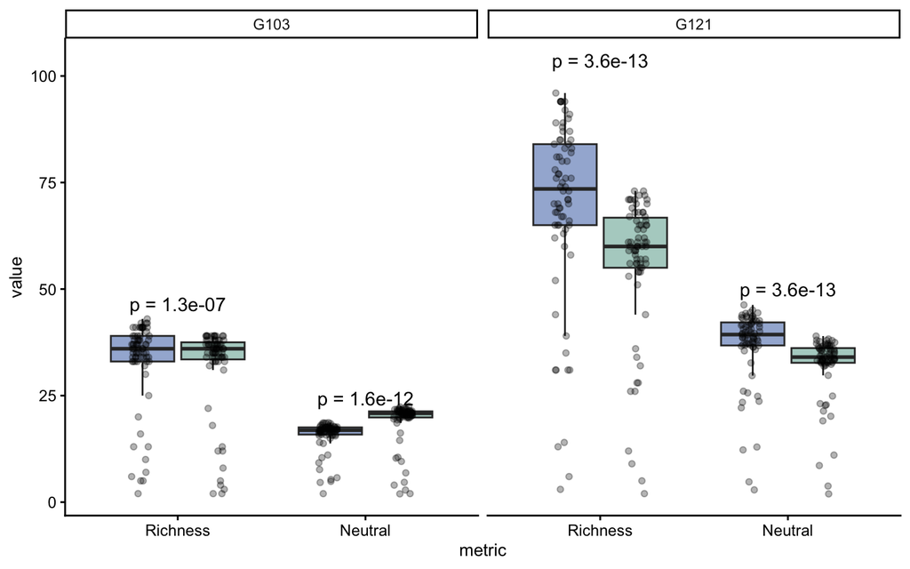

```r
plot_df <- cat_alpha_df_lg %>%
  filter(
    metric != "phylogenetic",
    (metric == "neutral" & value > 1) |
      (metric == "richness" & value > 0)
  ) %>%
  mutate(
    animal = recode(animal, "G121e" = "G121", "G103b" = "G103"),
    metric = fct_recode(
      metric,
      "Richness" = "richness",
      "Neutral" = "neutral"
    )
  )

pval_pos <- plot_df %>%
  group_by(animal, metric) %>%
  summarise(y = max(value, na.rm = TRUE) * 1.08, .groups = "drop") %>%
  left_join(pvals, by = c("animal", "metric"))

figs7_a <- ggplot(plot_df, aes(x = metric, y = value, fill = `MAG Catalogue`)) +
  geom_boxplot(alpha = 0.6, outlier.shape = NA) +
  geom_jitter(
    position = position_jitterdodge(
      jitter.width = 0.2,
      dodge.width = 0.8
    ),
    size = 1.5,
    alpha = 0.3
  ) +
  geom_text(
    data = pval_pos,
    aes(x = metric, y = y, label = label),
    inherit.aes = FALSE
  ) +
  facet_wrap2(~ animal) +
  scale_fill_manual(values = c("#5c7fba", "#79b1a3")) +
  pnas_theme

figs7_a
```

We detected significant differences in alpha diversity between the two reference catalogues.

##### 3.6.5.2.1 Taxa Overlap (Suppl.Fig. 8)

**Note:** The pivot_phylo() and compare_taxa_overlap() function needs to be loaded.

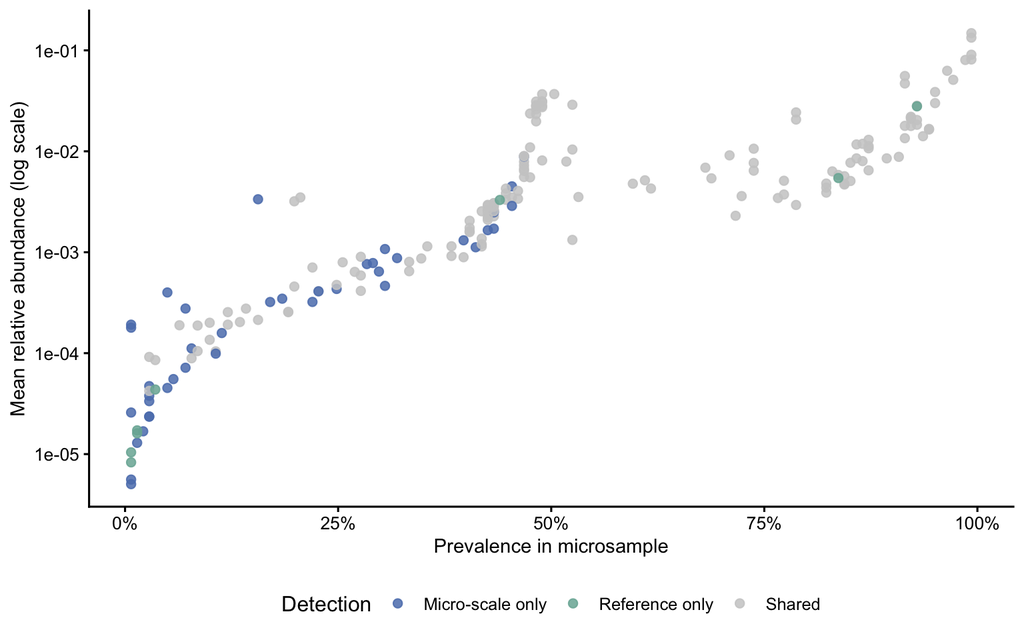

```r
cat_phylo_lg <- pivot_phylo(
  phyloseq_obj = subset_samples(
    cat_physeq_species
  ),
  glom = TRUE,
  tax_transform = TRUE,
  taxon_level = "species",
  tr_method = "compositional" # remove this
)

cat_taxa <- compare_taxa_overlap(
  data = cat_phylo_lg,
  group_var = "dataset",
  group_a = "Micro-scale",
  group_b = "Reference",
  taxon_var = "species",
  abundance_var = "abundance",
  sample_var = "microsample"
)

cat_taxa_plot <- ggplot(cat_taxa$plot_df,
       aes(x = prevalence,
           y = mean_abundance,
           color = Detection)) +
  geom_point(size = 2, alpha = 0.85)  +
  scale_color_manual(
    values = c(
      "Micro-scale only" = "#5c7fba",
      "Reference only" = "#79b1a3",
      "Shared" = "grey80"
    )
  ) +
  scale_y_log10(labels = scales::label_scientific()) +
  scale_x_continuous(labels = scales::percent_format()) +
  labs(
    x = "Prevalence in microsample",
    y = "Mean relative abundance (log scale)"
    ) +
  pnas_theme + theme(legend.position = "bottom")
cat_taxa_plot
```

```r
cat_taxa$plot_df %>%
  distinct(Detection, species) %>%
  count(Detection, name = "Number of species") %>%
  arrange(Detection)  %>%
  knitr::kable(
    col.names = c("Detection category", "Number of species"),
    align = c("l", "r"))
```

| Detection category | Number of species |
| --- | --- |
| Micro-scale only | 40 |
| Reference only | 8 |
| Shared | 77 |

A greater number of unique taxa were detected for the microscale catalogue.

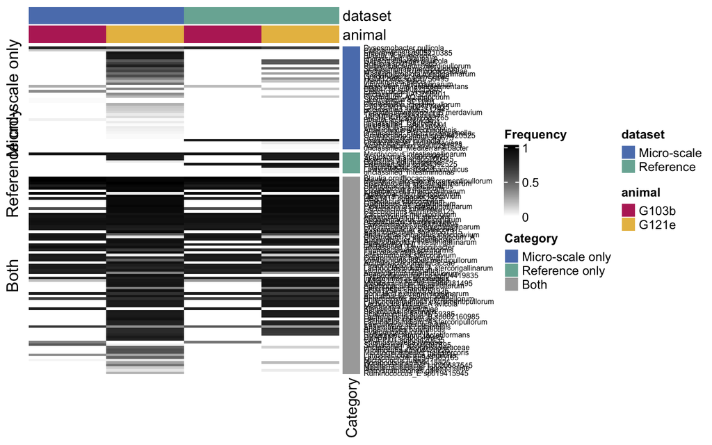

```r
cat_taxa <- compare_taxa_overlap(
  data = cat_phylo_lg,
  group_var = "dataset",
  group_a = "Micro-scale",
  group_b = "Reference",
  facet_var = "animal",
  taxon_var = "species",
  abundance_var = "abundance",
  sample_var = "microsample"
)

# ----------------------------
# 1. Prepare heatmap dataframe
# ----------------------------
heatmap_df <- cat_taxa$plot_df %>%
  mutate(
    column_id = paste(dataset, animal, sep = "_"),
    Detection = recode(
      Detection,
      "Shared" = "Both"
    )
  ) %>%
  select(species, dataset, animal, column_id, prevalence, Detection)

# ----------------------------
# 2. Frequency matrix
# ----------------------------
freq_mat <- heatmap_df %>%
  select(species, column_id, prevalence) %>%
  tidyr::pivot_wider(
    names_from = column_id,
    values_from = prevalence,
    values_fill = 0
  ) %>%
  tibble::column_to_rownames("species") %>%
  as.matrix()

# ----------------------------
# 3. Row classification
# ----------------------------
species_label <- heatmap_df %>%
  distinct(species, Detection) %>%
  mutate(
    Detection = factor(
      Detection,
      levels = c("Micro-scale only", "Reference only", "Both")
    )
  ) %>%
  arrange(Detection, species)

# keep matrix rows aligned with row annotation
freq_mat <- freq_mat[species_label$species, , drop = FALSE]

row_category <- species_label$Detection
names(row_category) <- species_label$species

# ----------------------------
# 4. Column annotation
# ----------------------------
annotation_col <- heatmap_df %>%
  distinct(column_id, dataset, animal) %>%
  arrange(dataset, animal) %>%
  tibble::column_to_rownames("column_id")

freq_mat <- freq_mat[, rownames(annotation_col), drop = FALSE]

# ----------------------------
# 5. Color scale
# ----------------------------
col_fun <- circlize::colorRamp2(
  c(0, max(freq_mat, na.rm = TRUE)),
  c("white", "black")
)

# ----------------------------
# 6. Row annotation
# ----------------------------
row_ha <- ComplexHeatmap::rowAnnotation(
  Category = row_category,
  col = list(
    Category = c(
      "Micro-scale only" = "#5c7fba",
      "Reference only" = "#79b1a3",
      "Both" = "darkgrey"
    )
  )
)

# ----------------------------
# 7. Column annotation
# ----------------------------
col_ha <- ComplexHeatmap::HeatmapAnnotation(
  dataset = annotation_col$dataset,
  animal = annotation_col$animal,
  col = list(
    dataset = c(
      "Micro-scale" = "#5c7fba",
      "Reference" = "#79b1a3"
    ),
    animal = c(
      "G121e" = "#E8BD50",
      "G103b" = "#B92D65"
    )
  )
)

# ----------------------------
# 8. Heatmap
# ----------------------------
ht <- ComplexHeatmap::Heatmap(
  freq_mat,
  name = "Frequency",
  col = col_fun,

  top_annotation = col_ha,
  right_annotation = row_ha,

  cluster_rows = FALSE,
  cluster_columns = FALSE,

  row_split = row_category,
  row_labels = rownames(freq_mat),

  show_row_names = TRUE,
  show_column_names = FALSE,

  row_names_gp = grid::gpar(fontsize = 6),
  row_names_max_width = grid::unit(4, "cm")
)

ht
```

```r
#pdf("figures/figs8_PNAS.pdf", width = 7.5, height = 10)
#draw(ht, heatmap_legend_side = "right", annotation_legend_side = "right")
#dev.off()
#png("figures/figs8_PNAS.png", width = 7.5, height = 10, units = "in", res = 300)
#draw(ht, heatmap_legend_side = "right", annotation_legend_side = "right", merge_legends = TRUE)
#dev.off()
```

#### 3.6.5.3 Beta Diversity (Suppl.Fig. 7b)

```r
cat_betacount_df <- data.frame(otu_table(cat_physeq_species)) %>%
  rownames_to_column("genome") %>%
  melt(id = "genome") %>%
  setNames(c("genome", "microsample", "count")) %>%
  left_join(data.frame(tax_table(sn1_physeq_species)) %>%
    rownames_to_column("genome"), by = "genome") %>%
  select(species, microsample, count) %>%
  filter(count > 0) %>%
  pivot_wider(names_from = species, values_from = count, values_fill = 0) %>% # change here
  select(where(~ any(. != 0))) %>%
  mutate(across(-microsample, ~ . / rowSums(across(where(is.numeric))) * 100)) %>%
  column_to_rownames(var = "microsample")
```

##### Centered Log-Ratio (CLR) Transformation And Principal Component Analysis (PCA)

**Note:** The perform_pca() function needs to be loaded.

```r
# cat("Zero replacement determined", "\n")
cat_beta_obj <- perform_pca(cat_betacount_df)
```

```
[1] "Zeros found"
```

```
No. adjusted imputations:  1410
Rows (samples) removed after zero replacement: 26
Columns (taxa) removed after zero replacement: 47
```

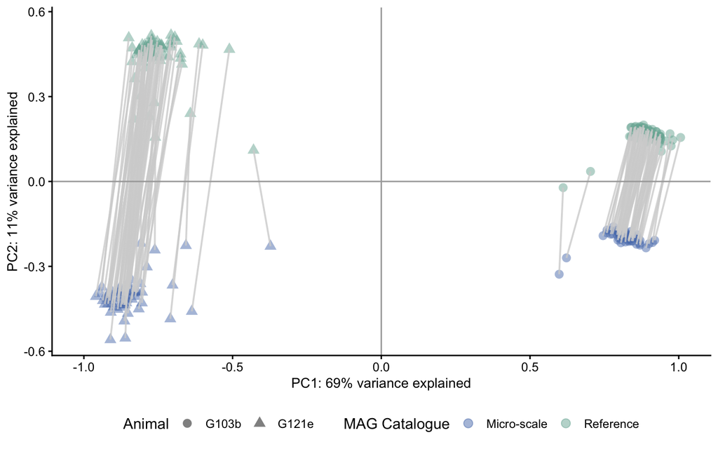

```r
cat_beta_metadata <- data.frame(sample_data(cat_physeq_species)) %>%
  rownames_to_column("microsample") %>%
  filter(microsample %in% c(rownames(cat_beta_obj$df_clr))) %>%
  rename(
    `MAG Catalogue` = dataset,
    Animal = animal
  )

cat_scores <- rownames_to_column(as.data.frame(cat_beta_obj$pca_result$x), var = "microsample")
cat_scores <- left_join(cat_scores, cat_beta_metadata, by = join_by(microsample == microsample))
variance_explained <- (cat_beta_obj$pca_result$sdev^2) / sum(cat_beta_obj$pca_result$sdev^2) * 100
figs7_b <- ggplot() +
  geom_point(
    data = cat_scores,
    aes(x = PC1, y = PC2, group = microsample, color = `MAG Catalogue`, shape = Animal),
    size = 3, alpha = 0.5
  ) +
  scale_color_manual(values = c("#5c7fba", "#79b1a3")) +
  geom_path(
    data = cat_scores,
    aes(x = PC1, y = PC2, group = sample_id),
    linewidth = 0.7, alpha = 0.8, color = "lightgrey"
  ) +
  labs(
    # title = "b",
    x = paste0("PC1: ", round(variance_explained[1], 0), "% variance explained"),
    y = paste0("PC2: ", round(variance_explained[2], 0), "% variance explained")
  ) +
  scale_x_continuous(limits = c(-max(abs(cat_scores$PC1)), max(abs(cat_scores$PC1)))) + # Calculate symmetric limits based on data
  scale_y_continuous(limits = c(-max(abs(cat_scores$PC2)), max(abs(cat_scores$PC2)))) + # Calculate symmetric limits based on data
  geom_hline(yintercept = 0, color = "darkgrey") + # Horizontal line at y = 0
  geom_vline(xintercept = 0, color = "darkgrey") + # Vertical line at x = 0
  pnas_theme +
  theme(legend.position = "bottom")
figs7_b
```

```r
figs7 <- figs7_a / figs7_b +
  plot_layout(heights = c(1, 1)) +
  plot_annotation(tag_levels = "a") &
  theme(plot.margin = margin(5, 5, 5, 5))


#ggsave( "figures/figs7_PNAS.pdf",
#  plot = figs7, width = 7.5, height = 6.5, device = cairo_pdf
#)

#ggsave("figures/figs7_PNAS.png",
#  plot = figs7, width = 7.5, height = 6.5, dpi = 300
#)
```

The 35-day-old animal (G121e) showed the greatest species-level differences between catalogues.

##### Differential Abundance (Aldex2)

```r
structural_zero <- data.frame(otu_table(tax_glom(cat_physeq_G121e, taxrank = "species"))) %>%
  rownames_to_column("genome") %>%
  pivot_longer(cols = -c(genome), names_to = "microsample", values_to = "abundance") %>%
  mutate(dataset = str_sub(microsample, -5, -1)) %>%
  group_by(dataset, genome) %>%
  summarise(sum_abundance = sum(abundance)) %>%
  filter(sum_abundance == 0) %>%
  pull(genome)

cat_aldex_G121e_counts <- data.frame(otu_table(tax_glom(cat_physeq_G121e, "species"))) # %>%
# rownames_to_column("genome") %>%
# filter(!genome %in%c(structural_zero)) %>%
# column_to_rownames("genome")
cat_aldex_G121e_pseudo_counts <- round(cat_aldex_G121e_counts * 1e6)
cat_aldex_G121e_conditions <- data.frame(sample_data(tax_glom(cat_physeq_G121e, "species"))) %>% pull(dataset)
cat_aldex_G121e_results <- aldex(cat_aldex_G121e_pseudo_counts,
  cat_aldex_G121e_conditions,
  test = "t",
  effect = TRUE, # include effect sizes
  denom = "all", # normalization denominator
  mc.samples = 256, # number of Monte Carlo instances
  verbose = TRUE
)
```

```
|------------(25%)----------(50%)----------(75%)----------|
```

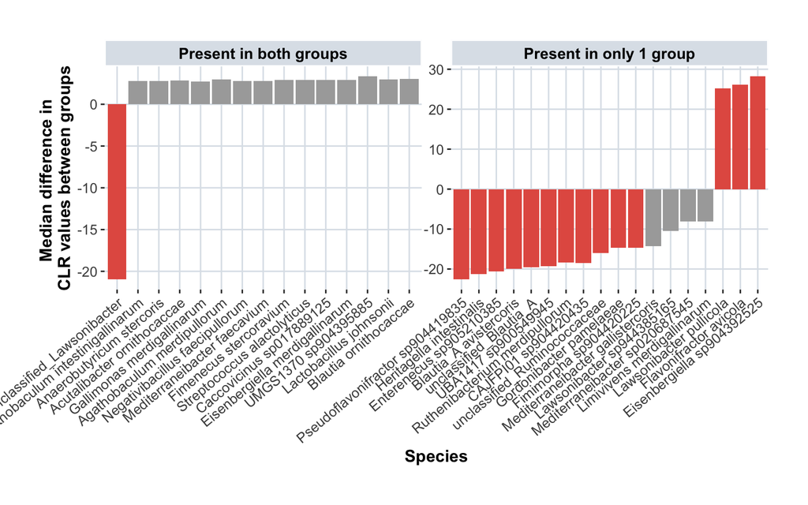

```r
# - we.ep: expected p-value from Welch's t-test
# - wi.ep: expected p-value from Wilcoxon test
# - we.eBH: BH-adjusted p-value (q-value)
# - effect: effect size (difference in clr means / variability)
# Filter
cat_aldex_G121e_sig <- cat_aldex_G121e_results[cat_aldex_G121e_results$we.eBH < 0.05, ]
cat_aldex_G121e_effect <- cat_aldex_G121e_sig[abs(cat_aldex_G121e_sig$effect) > 0.5, ]
cat_aldex <-
  cat_aldex_G121e_effect %>%
  rownames_to_column("genome") %>%
  left_join(data.frame(tax_table(tax_glom(cat_physeq_G121e, "species"))) %>% rownames_to_column("genome"), by = "genome")

cat_aldex_plot <- cat_aldex %>%
  mutate(structural_zero = ifelse(genome %in% c(structural_zero), "Present in only 1 group", "Present in both groups")) %>%
  ggplot(., aes(x = diff.btw, y = reorder(species, effect), fill = abs(effect) > 1)) +
  geom_bar(stat = "identity", show.legend = FALSE) +
  coord_flip() +
  labs(
    x = "Median difference in \nCLR values between groups",
    y = "Species"
  ) +
  scale_fill_manual(values = c("TRUE" = "#e35d51", "FALSE" = "darkgrey")) +
  custom_ggplot_theme +
  facet_wrap(~structural_zero, scale = "free") +
  theme(axis.text.x = element_text(angle = 40, hjust = 1))
cat_aldex_plot
```

Differentially abundant species in the 35-day-old animal (G121e) are primarily structural 0.

## 3.7 Environmental and host contamination

### 3.7.1 Controls Sequencing Performance (Suppl.Fig. 9)

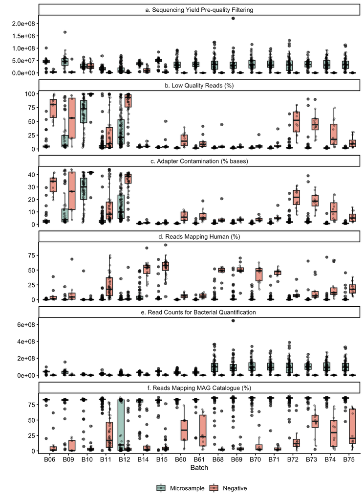

```r
ordered_metrics <- c(
  "total_before_filtering.total_reads",
  "lowquality_reads_pct",
  "adapter_contamination_pct",
  "human_pct",
  "raw_total_sequences_mag",
  "mapmag_prokreads_pct"
)

figs9 <- macroquant_metrics_filt_30 %>%
  filter(!section %in% c("Ileum")) %>%
  mutate(
    batch = gsub("MSEB00", "B", batch),
    lowquality_reads_pct = lowquality_reads_pct * 100,
    adapter_contamination_pct = adapter_contamination_pct * 100,
    human_pct = human_pct * 100,
    mapmag_prokreads_pct = mapmag_prokreads_pct * 100
  ) %>%
  pivot_longer(
    cols = -c(names(mssm_sample_metadata), "cov_filtering"),
    names_to = "metric",
    values_to = "value"
  ) %>%
  filter(metric %in% ordered_metrics) %>%
  mutate(
    metric = factor(metric, levels = ordered_metrics),
    metric = fct_recode(metric,
      "a. Sequencing Yield Pre-quality Filtering" = "total_before_filtering.total_reads",
      "b. Low Quality Reads (%)" = "lowquality_reads_pct",
      "c. Adapter Contamination (% bases)" = "adapter_contamination_pct",
      "d. Reads Mapping Human (%)" = "human_pct",
      "e. Read Counts for Bacterial Quantification " = "raw_total_sequences_mag",
      "f. Reads Mapping MAG Catalogue (%)" = "mapmag_prokreads_pct"
    ),
    type = recode(type,
      "positive" = "Microsample",
      "negative" = "Negative"
    )
  ) %>%
  ggplot(aes(x = batch, y = value, fill = type)) +
  geom_boxplot(alpha = 0.6) +
  facet_wrap(~metric, scales = "free_y", ncol = 1) +
  labs(
    fill = "",
    y = "",
    x = "Batch"
  ) +
  # geom_violin(trim = TRUE, alpha = 0.7, position = position_dodge(0.8), na.rm = TRUE) +  # Violin plot
  geom_jitter(
    position = position_jitterdodge(jitter.width = 0.2, dodge.width = 0.8),
    size = 1, alpha = 0.3
  ) +
  scale_fill_manual(values = c("#79b1a3", "#E76F51")) +
  custom_ggplot_theme +
  pnas_theme + theme(legend.position = "bottom")

figs9
```

```r
#ggsave("figures/figs9_PNAS.png",
#  plot = figs9, width = 7.5, height = 10, dpi = 300
#)
```

Although controls yielded sequencing data, they consistently exhibited poorer quality metrics.

### 3.7.2 Host Contamination (Suppl.Fig. 10)

```r
format_median_iqr(macroquant_metrics_filt_30 %>%
  filter(type == "positive", richness > 0) %>%
  mutate(host_pct = host_pct * 100) %>%
  pull(host_pct))
```

```
[1] "0.0 (0.0–0.1)"
```

```r
host_df <- macroquant_metrics_filt_30 %>%
  filter(type == "positive", richness > 0) %>%
  mutate(
    host = host_pct * 100,
    host_log = log(host + 1e-6)
  )

df_bin <- host_df  %>% # binned summary (geometric mean + CI)
  mutate(bin = ntile(distance_host, 10)) %>%
  group_by(bin) %>%
  summarise(
    distance_mid = mean(distance_host),
    mean_log = mean(host_log),
    mean_host = mean(host),
    se_log = sd(host_log) / sqrt(n()),
    lower = exp(mean_log - 1.96 * se_log),
    upper = exp(mean_log + 1.96 * se_log),
    mean_host = exp(mean_log),
    .groups = "drop"
  )

figs10 <- ggplot(df, aes(x = distance_host, y = host)) +
  geom_point(alpha = 0.3, size = 1.5) +
  geom_ribbon(
    data = df_bin,
    aes(x = distance_mid, ymin = lower, ymax = upper),
    inherit.aes = FALSE,
    fill = "grey70",
    alpha = 0.5
  ) +
  geom_line(
    data = df_bin,
    aes(x = distance_mid, y = mean_host),
    inherit.aes = FALSE,
    color = "black",
    size = 1
  ) +
  scale_y_log10() +
  labs(
    x = "Distance to host (µm)",
    y = "Host reads (%) (log scale)"
  ) +
  pnas_theme

#ggsave("figures/host_distance_final.pdf",
#  plot = p_raw, width = 7.5, height = 3.5, device = cairo_pdf
#)

#ggsave("figures/host_distance_final.png",
#   plot = p_raw,width = 7.5, height = 3.5, dpi = 300
#)
```

## 3.8 Discriminative power and replicability of MSSM data

```r
mssm_discriminative_df <- macroquant_genome_counts_filt_30 %>%
  select(genome, macroquant_metrics_filt_30 %>%
    filter(
      batch %in% c("MSEB0011", "MSEB0060", "MSEB0061"),
      type %in% c("positive")
    ) %>% pull(microsample)) %>%
  select(where(~ !all(. == 0))) %>%
  melt(id = "genome") %>%
  setNames(c("genome", "microsample", "count")) %>%
  pivot_wider(names_from = genome, values_from = count, values_fill = 0) %>%
  select(where(~ any(. != 0))) %>%
  mutate(across(-microsample, ~ . / rowSums(across(where(is.numeric))) * 100)) %>%
  column_to_rownames(var = "microsample")
```

### 3.8.1 Centered Log-Ratio (CLR) Transformation And Principal Component Analysis (PCA, Suppl Fig. 5)

**Note:** The perform_pca() function needs to be loaded.

```r
# cat("Zero replacement determined", "\n")
mssm_discriminative_obj <- perform_pca(mssm_discriminative_df)
```

```
[1] "Zeros found"
```

```
No. adjusted imputations:  2246
Rows (samples) removed after zero replacement: 18
Columns (taxa) removed after zero replacement: 25
```

```r
mssm_discriminative_metadata <- macroquant_metrics_filt_30 %>%
  filter(microsample %in% c(rownames(mssm_discriminative_obj$df_clr_dist)))
```

```r
#figs_4 <- plot_pca(mssm_discriminative_obj$pca_result,
#         samples_color_metadata = "animal",
#         samples_shape_metadata = "cryosection",
#         samples_color_value = c('#ffc273','#c1558b'),
#         loadings_color_metadata = "order",
#          loadings_color_value = order_colors,
#          loadings_taxon_level = "species",
#          sample_metadata = mssm_discriminative_metadata,
#          genome_metadata = macromag_genomemetadata,
#          custom_ggplot_theme = custom_ggplot_theme,
#          order_colors, loadings_number = 20)
# figs_4
```

### 3.8.2 Permutational Multivariate Analysis of Variance (PERMANOVA)

#### Tests Homogeneity Of Dispersion Between Groups

##### Animal

```r
set.seed(123)
betadisper_animal <- vegdist(mssm_discriminative_obj$df_clr_dist, method = "euclidean") %>%
  betadisper(., mssm_discriminative_metadata %>% pull(animal))
knitr::kable(permutest(betadisper_animal, pairwise = TRUE, permutations = 9999)$tab, digits = 4)
```

|  | Df | Sum Sq | Mean Sq | F | N.Perm | Pr(>F) |
| --- | --- | --- | --- | --- | --- | --- |
| Groups | 1 | 178.7233 | 178.7233 | 139.6636 | 9999 | 1e-04 |
| Residuals | 286 | 365.9856 | 1.2797 | NA | NA | NA |

##### Cryosection

```r
betadisper_cryo <- vegdist(mssm_discriminative_obj$df_clr_dist, method = "euclidean") %>%
  betadisper(., mssm_discriminative_metadata %>% pull(cryosection))
knitr::kable(permutest(betadisper_cryo, pairwise = TRUE)$tab, digits = 3)
```

|  | Df | Sum Sq | Mean Sq | F | N.Perm | Pr(>F) |
| --- | --- | --- | --- | --- | --- | --- |
| Groups | 6 | 197.550 | 32.925 | 45.078 | 999 | 0.001 |
| Residuals | 281 | 205.244 | 0.730 | NA | NA | NA |

```r
knitr::kable(permutest(betadisper_cryo, pairwise = TRUE, permutations = 9999)$tab, digits = 4)
```

|  | Df | Sum Sq | Mean Sq | F | N.Perm | Pr(>F) |
| --- | --- | --- | --- | --- | --- | --- |
| Groups | 6 | 197.5504 | 32.9251 | 45.0777 | 9999 | 1e-04 |
| Residuals | 281 | 205.2443 | 0.7304 | NA | NA | NA |

#### 3.8.2.1 PERMANOVA

```r
knitr::kable(vegdist(mssm_discriminative_obj$df_clr_dist, method = "euclidean") %>%
  adonis2(
    formula = . ~ animal * cryosection,
    data = mssm_discriminative_metadata,
    permutations = 9999, by = "terms"
  ) %>%
  broom::tidy(), digits = 3)
```

| term | df | SumOfSqs | R2 | statistic | p.value |
| --- | --- | --- | --- | --- | --- |
| animal | 1 | 16023.589 | 0.868 | 2542.887 | 0 |
| cryosection | 5 | 662.321 | 0.036 | 21.022 | 0 |
| Residual | 281 | 1770.676 | 0.096 | NA | NA |
| Total | 287 | 18456.586 | 1.000 | NA | NA |

MSSM data across individuals revealed highly distinct microbial communities. In contrast, differences among sequential cryosections of the same individual, were negligible.

## 3.9 MSSM compared to FISH and Macro-scale Metagenomics

### 3.9.1 MSSM vs FISH

```r
custom_ggplot_theme_fish_mssm <- custom_ggplot_theme +
  theme(
        legend.text = element_text(size = 7),
        legend.title = element_text(size = 7),
        axis.text = element_text(size = 5),
        axis.title = element_text(size = 7, face = "bold"),
        strip.text = element_text(size = 7, face = "bold", color = "black"),
        plot.title = element_text(size = 7, face = "bold", color = "black"),
        plot.margin = unit(c(0, 0, 0, 0), "cm"))
```

#### 3.9.1.1 PCA (Fig. 4b)

```r
# Load FISH counts as wide df
fish_df_wide <- fish_counts %>%
  select(-Total, -animal, -cryosection, -sample_type, -Other) %>%
  select(where(~ any(. != 0)) | where(is.character) | where(is.factor)) %>%
  mutate(across(-c(microsample), ~ . / rowSums(across(where(is.numeric))) * 100 )) %>%
  column_to_rownames(var = "microsample")

# Create a tidy MSSM df with the relevant data
mssm_df_wide <- macroquant_genome_counts_filt_30_tidy %>%
  filter(type == "positive") %>%
  filter(batch == "MSEB0011") %>%
  # filter(mapmag_filteredreads_pct > 0.8) %>%
  select(domain, phylum, class, order, family, genus, genome, microsample, count) %>%
  group_by(microsample, genus) %>%
  summarise(genus_count = sum(count, na.rm = TRUE))%>%
  filter(genus != "") %>%
  mutate(count=genus_count) %>%
  select(-genus_count) %>%
  pivot_wider(names_from = genus,values_from = count,values_fill = 0) %>%
  select(where(~ any(. != 0)) | where(is.character) | where(is.factor)) %>%
  column_to_rownames(var = "microsample") #%>%

# Remove almost empty samples or taxa from entire MSSM df
mssm_df_wide <- remove_samples_or_taxa(df = mssm_df_wide,
                                       min_samples_per_taxon = 30,
                                       min_taxa_per_sample = 26)
```

```
Initial df: Rows (samples): 141 , Columns (taxa): 60
Removed: Rows (samples): 22 , Columns (taxa): 10
Resulting df: Rows (samples): 119 , Columns (taxa): 50
```

```r
# Sum all other genera into "Other"
mssm_df_wide <- mssm_df_wide %>%
  mutate(Other = rowSums(select(., -all_of(fish_selected_genera)), na.rm = TRUE)) %>%
  # Keep only the selected genera
  select(any_of(fish_selected_genera)) %>%
  mutate(across(where(is.numeric), ~ . / rowSums(across(where(is.numeric))) * 100))

# Combine the dfs for MSSM and FISH
fish_mssm_df_wide <- bind_rows(fish_df_wide, mssm_df_wide)
fish_mssm_sample_metadata <- bind_rows(
  fish_sample_metadata,
  macroquant_metrics_filt_30 %>%
    filter(type == "positive", batch == "MSEB0011") %>%
    select(microsample, animal, cryosection) %>%
    mutate(sample_type = "MSSM")
)
# Perform PCA
fish_mssm_pca <- perform_pca(fish_mssm_df_wide, z_delete = TRUE)
```

```
[1] "Zeros found"
No. adjusted imputations:  4
Rows (samples) removed after zero replacement: 0
Columns (taxa) removed after zero replacement: 0
```

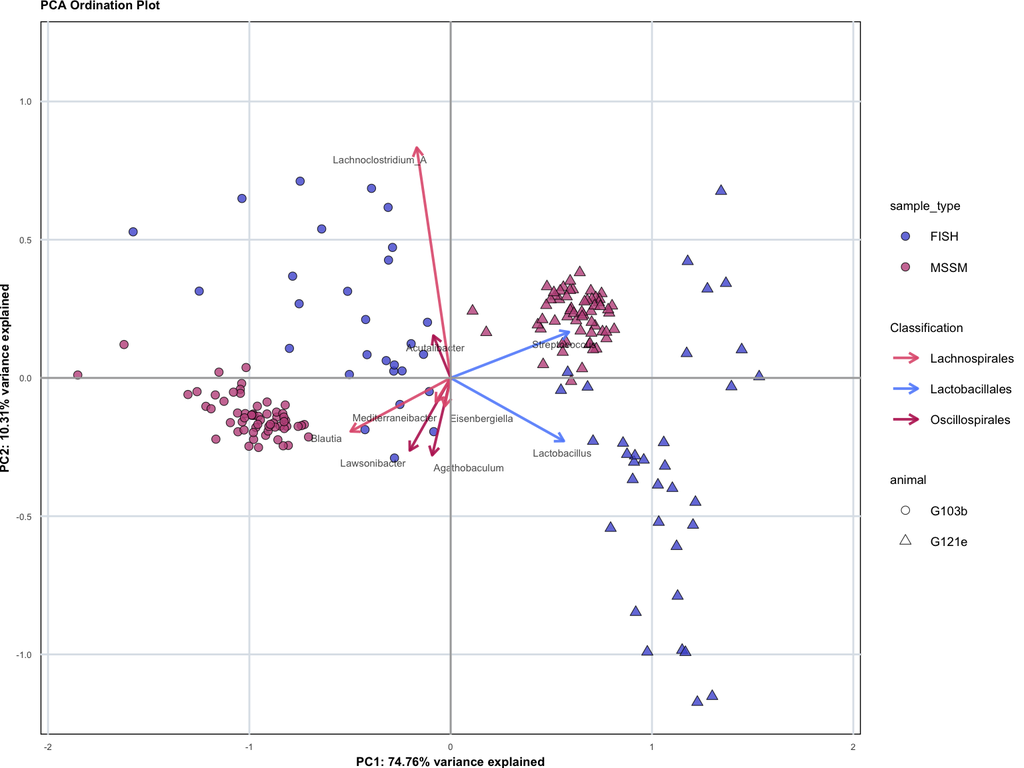

```r
fig4_b <- plot_pca(fish_mssm_pca$pca_result,
                   samples_color_metadata = "sample_type",
                   samples_shape_metadata = "animal",
                   samples_color_value = c('#4f5bd5', '#c1558b'),
                   loadings_color_metadata = "order",
                   loadings_color_value = order_colors,
                   loadings_taxon_level = "genus",
                   sample_metadata = fish_mssm_sample_metadata,
                   genome_metadata = fish_genome_metadata,
                   scaling_factor_value = 1,
                   order_colors,
                   custom_ggplot_theme_fish_mssm)
fig4_b
```

#### 3.9.1.2 PERMANOVA

```r
# Calculate Euclidean distance on CLR data
fish_mssm_dist_matrix <- vegdist(fish_mssm_pca$df_clr_dist, method = "euclidean")

# Make sure that filtered df and metadata have the same number & order of rows
fish_mssm_metadata_adonis <- fish_mssm_sample_metadata %>%
  filter(microsample %in% rownames(fish_mssm_pca$df_clr_dist)) %>%
  arrange(match(microsample, rownames(fish_mssm_pca$df_clr_dist)))
all(fish_mssm_metadata_adonis$microsample == rownames(fish_mssm_pca$df_clr_dist))
```

```
[1] TRUE
```

```r
# Run PERMANOVA
adonis2_result <- adonis2(
  fish_mssm_dist_matrix ~ animal + sample_type,
  data = fish_mssm_metadata_adonis,
  permutations = 9999,
  by = "terms"
)
adonis2_result %>%
  knitr::kable()
```

|  | Df | SumOfSqs | R2 | F | Pr(>F) |
| --- | --- | --- | --- | --- | --- |
| animal | 1 | 518.68087 | 0.6533052 | 427.36850 | 1e-04 |
| sample_type | 1 | 59.22082 | 0.0745917 | 48.79516 | 1e-04 |
| Residual | 178 | 216.03182 | 0.2721032 | NA | NA |
| Total | 180 | 793.93351 | 1.0000000 | NA | NA |

#### 3.9.1.3 Fig. 4a

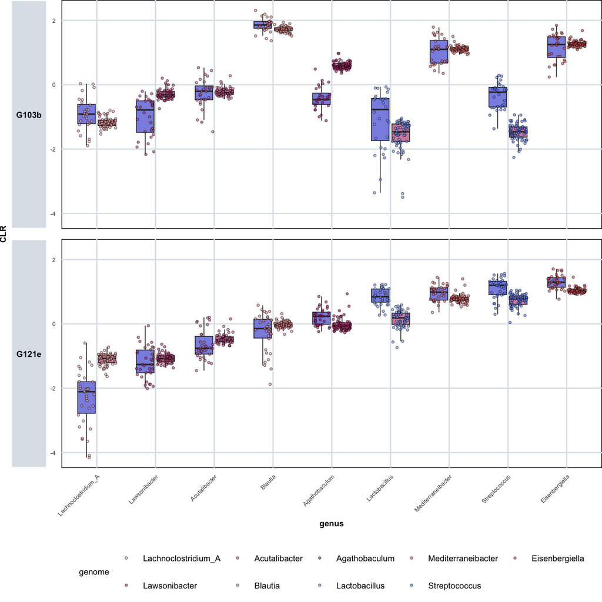

```r
fish_mssm_df_CLR_tidy <- fish_mssm_pca$df_clr_dist %>%
  rownames_to_column(var = "microsample") %>%
  pivot_longer(
    cols = -microsample,
    names_to = "genome",
    values_to = "relabun"
  ) %>%
  left_join(fish_genome_metadata, by = join_by(genome == genome)) %>%
  left_join(fish_mssm_sample_metadata, by = join_by(microsample == microsample)) %>%
  mutate(
    phylum = factor(phylum, levels = unique(fish_genome_metadata$phylum)),
    order = factor(order, levels = unique(fish_genome_metadata$order))
  )

# Order the genera based on abundance in animal G121 for plot
summary <- fish_mssm_df_CLR_tidy %>%
  filter(animal == "G121e") %>%
  group_by(genome) %>%
  summarise(mean = mean(relabun, na.rm = T)) %>%
  arrange(-mean)

# Plot barplot of CLR values per animal, for MSSM and FISH
fig4_a <- fish_mssm_df_CLR_tidy %>%
  mutate(genome = factor(genome, levels = rev(summary %>% pull(genome)))) %>%
  ggplot(aes(x = genome, y = relabun)) +
  geom_boxplot(aes(fill = sample_type),
    outlier.shape = NA, alpha = 0.7, width = 0.6, size = 0.3,
    position = position_dodge(width = 0.7)
  ) +
  scale_fill_manual(values = c('#4f5bd5', '#c1558b')) +
  guides(fill = "none") +
  new_scale_fill() +
  geom_jitter(aes(fill = genome, group = sample_type),
    size = 0.8, alpha = 0.6, shape = 21,
    color = "black",
    stroke = 0.3,
    position = position_jitterdodge(jitter.width = 0.6, dodge.width = 0.7)
  ) +
  scale_fill_manual(values = fish_genus_colors) +
  facet_nested(animal ~ ., scales = "fixed", space = "fixed", switch = "y") + # switch = "y"
  labs(x = "genus", y = "CLR") +
  theme_minimal() +
  custom_ggplot_theme_fish_mssm +
  theme(axis.text.x = element_text(angle = 45, hjust = 1)) + # Rotate x-axis labels
  theme(legend.position = "bottom") +
  theme(panel.spacing = unit(0.6, "lines"))
fig4_a
```

### 3.9.2 Macro-scale Metagenomics vs MSSM

##### 3.9.2.0.1 Taxa Overlap (Suppl.Fig. 11)

**Note:** The pivot_phylo() and compare_taxa_overlap() function needs to be loaded.

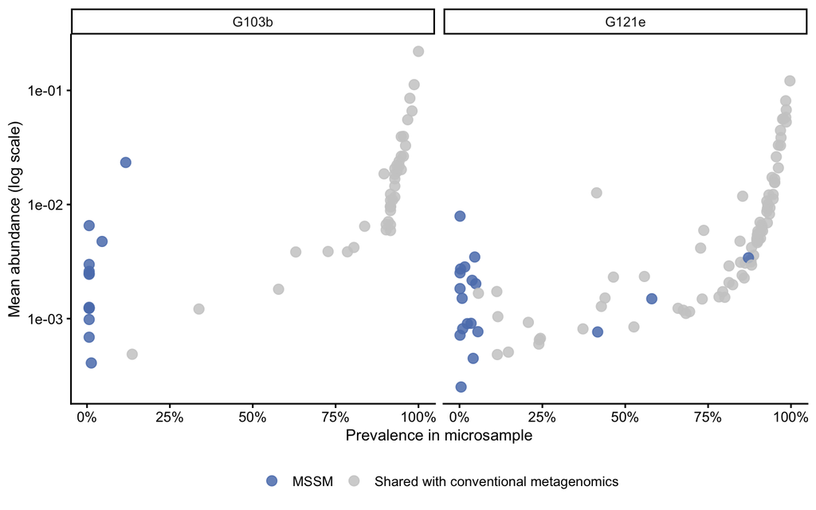

```r
mivsma_phylo_lg <- pivot_phylo(
  phyloseq_obj = subset_samples(
    physeq_all,
    type == "positive" & !section %in% c("Colon", "Ileum")
  ),
  glom = TRUE,
  tax_transform = TRUE,
  taxon_level = "species",
  tr_method = "compositional"
) %>%
  filter(abundance > 0)

species_presence <- mivsma_phylo_lg %>%
  filter(
    group %in% c(
      "Micro-scale Spatial Metagenomics",
      "Macro-scale Metagenomics"
    ),
    animal %in% c("G121e", "G103b"),
    !is.na(species)
  ) %>%
  distinct(animal, group, species) %>%
  mutate(present = TRUE) %>%
  tidyr::pivot_wider(
    names_from = group,
    values_from = present,
    values_fill = FALSE
  ) %>%
  mutate(
    Detection = case_when(
      `Micro-scale Spatial Metagenomics` &
        !`Macro-scale Metagenomics` ~ "MSSM",
      `Micro-scale Spatial Metagenomics` &
        `Macro-scale Metagenomics` ~ "Shared with conventional metagenomics",
      TRUE ~ NA_character_
    )
  ) %>%
  filter(!is.na(Detection))

sample_counts <- mivsma_phylo_lg %>%
  filter(
    group == "Micro-scale Spatial Metagenomics",
    animal %in% c("G121e", "G103b")
  ) %>%
  distinct(animal, microsample) %>%
  count(animal, name = "total_microsamples")


plot_df <- mivsma_phylo_lg %>%
  filter(
    group == "Micro-scale Spatial Metagenomics",
    animal %in% c("G121e", "G103b"),
    !is.na(species)
  ) %>%
  group_by(animal, microsample, species) %>%
  summarise(
    sample_abundance = sum(abundance, na.rm = TRUE),
    .groups = "drop"
  ) %>%
  group_by(animal, species) %>%
  summarise(
    mean_abundance = mean(sample_abundance, na.rm = TRUE),
    prevalence_raw = sum(sample_abundance > 0),
    .groups = "drop"
  ) %>%
  left_join(sample_counts, by = "animal") %>%
  mutate(
    prevalence = prevalence_raw / total_microsamples
  ) %>%
  left_join(
    species_presence %>%
      select(animal, species, Detection),
    by = c("animal", "species")
  ) %>%
  filter(!is.na(Detection))


fig_s11 <- ggplot(
  plot_df,
  aes(
    x = prevalence,
    y = mean_abundance,
    color = Detection
  )
) +
  geom_point(size = 3, alpha = 0.85) +
  facet_wrap(~ animal) +
  scale_color_manual(
    values = c(
      "MSSM" = "#5c7fba",
      "Shared with conventional metagenomics" = "grey80"
    )
  ) +
  scale_y_log10(labels = scales::label_scientific()) +
  scale_x_continuous(labels = scales::percent_format()) +
  labs(
    x = "Prevalence in microsample",
    y = "Mean abundance (log scale)",
    color = NULL
  ) +
  pnas_theme +
  theme(legend.position = "bottom")

fig_s11
```

```r
ggsave(
  "figures/fig_s11.pdf",
  plot = fig_s11,
  width = 7.5,
  height = 3.5,
  device = cairo_pdf
)

ggsave(
  "figures/fig_s11.png",
  plot = fig_s11,
  width = 7.5,
  height = 3.5,
  dpi = 300
)
```

## 3.10 Investigate Spatial Pattern

## 3.11 Subspecies Segregation and Spatial Structuring

### 3.11.1 Pangenome: Genes Presence/Absence (Suppl.Fig. 12a)

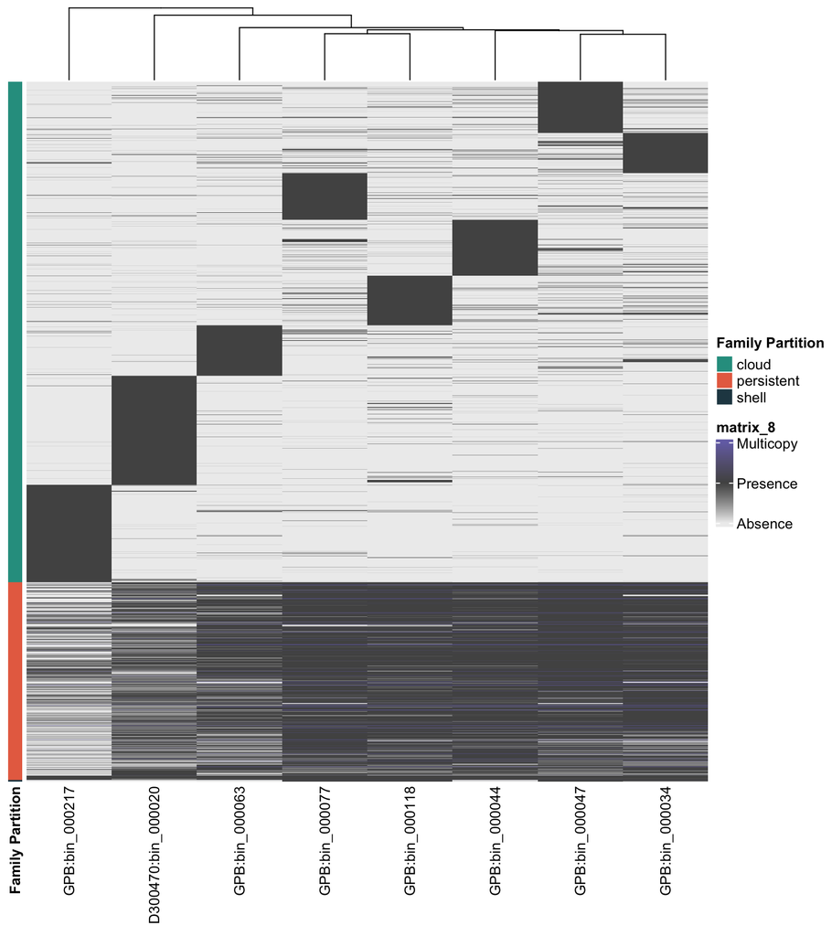

```r
wide_data <- left_join(genepa_pg, duplication_pg, by = "gene") %>%
  left_join(partition_pg, by = "gene") %>%
  pivot_longer(!c(gene, is_single_copy_marker, `Family Partition`), names_to = "Genome", values_to = "Presence/Absence") %>%
  mutate(`Presence/Absence` = as.character(`Presence/Absence`)) %>%
  mutate(`Presence/Absence` = case_when(
    `Presence/Absence` == "1" & is_single_copy_marker == "FALSE" ~ "2",
    TRUE ~ `Presence/Absence`
  )) %>%
  mutate(`Presence/Absence` = as.numeric(`Presence/Absence`)) %>%
  select(gene, Genome, `Presence/Absence`) %>%
  pivot_wider(names_from = Genome, values_from = `Presence/Absence`, values_fill = 0)
mat <- as.matrix(wide_data[, -1])
rownames(mat) <- wide_data$gene
gene_anno <- left_join(genepa_pg, duplication_pg, by = "gene") %>%
  left_join(partition_pg, by = "gene") %>%
  pivot_longer(!c(gene, is_single_copy_marker, `Family Partition`), names_to = "Genome", values_to = "Presence/Absence") %>%
  distinct(gene, `Family Partition`) %>%
  arrange(`Family Partition`) %>%
  column_to_rownames("gene")
mat <- mat[rownames(gene_anno), ]

ann_colors <- list(
  `Family Partition` = c(
    "cloud" = "#2A9D8F",
    "shell" = "#264653",
    "persistent" = "#E76F51"
  )
)

fig_s12a <- pheatmap(mat,
  color = c("0" = "grey93", "1" = "gray32", "2" = "#7570b3"), # Named colors
  annotation_row = gene_anno,
  annotation_colors = ann_colors,
  cluster_cols = TRUE,
  cluster_rows = FALSE,
  show_rownames = FALSE,
  legend_breaks = c(0, 1, 2),
  legend_labels = c("Absence", "Presence", "Multicopy")
)
fig_s12a
```

### 3.11.2 Distribution Lawsonibacter Strains (Suppl.Fig. 12b)

```r
macroquant_lawsonibacter <- macroquant_genome_counts_filt_30_98 %>%
  filter(genome %in% c(macromag_genomemetadata_98 %>%
    filter(genus == "Lawsonibacter") %>%
    pull(genome))) %>%
  pivot_longer(-genome, names_to = "microsample", values_to = "abundance") %>%
  left_join(macroquant_metrics_filt_30 %>%
    select(microsample, type, batch, cryosection, animal, Xcoord, Ycoord), by = "microsample") %>%
  filter(
    type == "positive",
    abundance > 0,
    !is.na(Xcoord),
    !is.na(Ycoord)
  ) %>%
  left_join(macromag_genomemetadata_98, by = "genome")

lawsonibacter_pie_df <- macroquant_lawsonibacter %>%
  #filter(
    #cryosection %in% c("G121eI103A", "G103bI301A"),
    # circul %in% c("Y")
  #) %>%
  group_by(microsample) %>%
  mutate(
    abundance = abundance / sum(abundance) # normalize counts to proportions
  ) %>%
  arrange(microsample, genome) %>%
  mutate(
    start = cumsum(lag(abundance, default = 0)) * 2 * pi,
    end = cumsum(abundance) * 2 * pi,
    r0 = 0,
    r = 75
  )

lawsonibacter_piecharts <- split(lawsonibacter_pie_df, lawsonibacter_pie_df$cryosection) %>%
  purrr::map(~ {
    ggplot(.x) +
      geom_arc_bar(
        aes(
          x0 = Xcoord, y0 = Ycoord, r0 = r0, r = r,
          start = start, end = end, fill = genome
        ),
        color = "black", linewidth = 0.1
      ) +
      coord_fixed() +
      ggtitle(unique(.x$cryosection)) +
      theme(legend.position = "none") +
      pnas_theme +
      scale_fill_manual(values = lawsonibacter_colors, drop = FALSE)
  })

macroquant_lawsonibacter %>%
  group_by(cryosection) %>%
  summarise(n_microsamples = n_distinct(microsample))
```

```
# A tibble: 10 × 2
   cryosection n_microsamples
   <chr>                <int>
 1 G103bI301A              33
 2 G103bI301B              30
 3 G121eI103A              31
 4 G121eI103B              30
 5 G121eI104C              47
 6 G121eI117A             155
 7 G121eI118B             113
 8 G121eO306A             141
 9 G121eO307A             106
10 G121eO308A              69
```

```r
unique(macroquant_lawsonibacter$cryosection)
```

```
 [1] "G121eI103A" "G103bI301A" "G121eI103B" "G103bI301B" "G121eI104C" "G121eO306A" "G121eI117A" "G121eO307A" "G121eI118B" "G121eO308A"
```

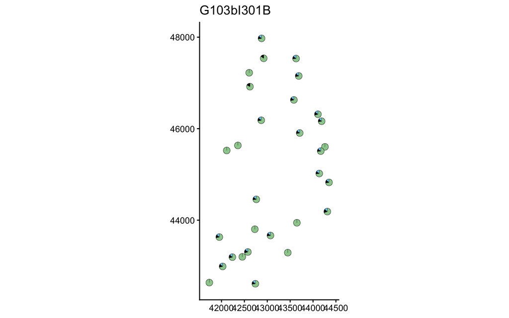

```r
# "G103bI301A" "G103bI301B"
# "G121eI103A" "G121eI103B"  "G121eI117A" "G121eI104C" "G121eI118B"
# "G121eO307A" "G121eO306A" "G121eO308A"

lawsonibacter_piecharts$G103bI301B
```

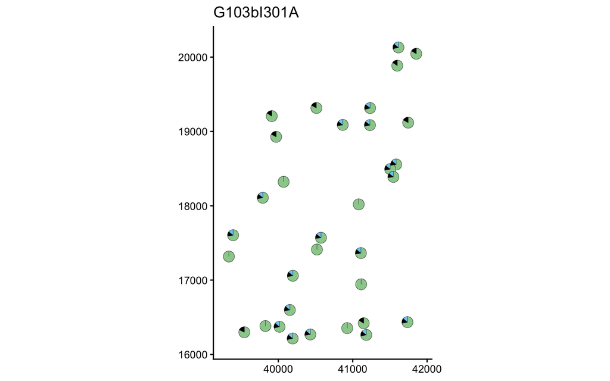

```r
lawsonibacter_piecharts$G103bI301A
```

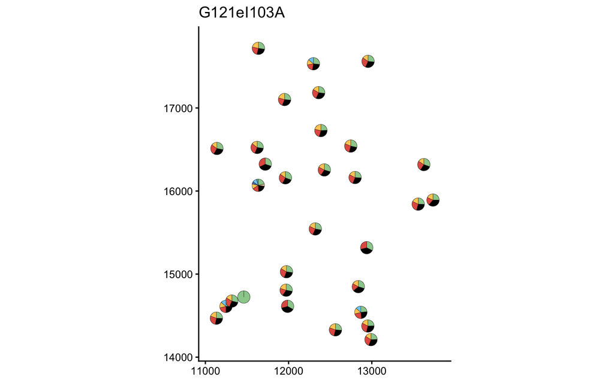

```r
# Extra
lawsonibacter_piecharts$G121eI103A
```

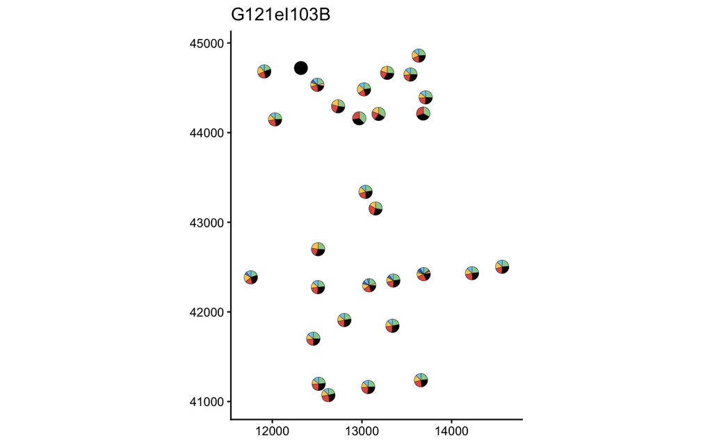

```r
lawsonibacter_piecharts$G121eI103B
```

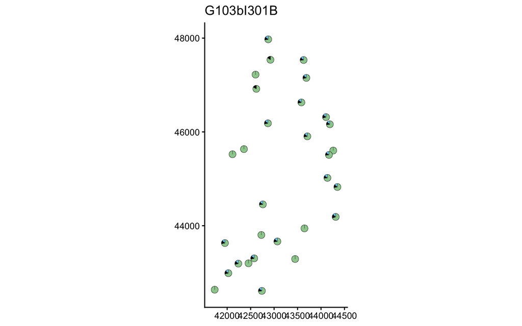

```r
lawsonibacter_piecharts$G103bI301B
```

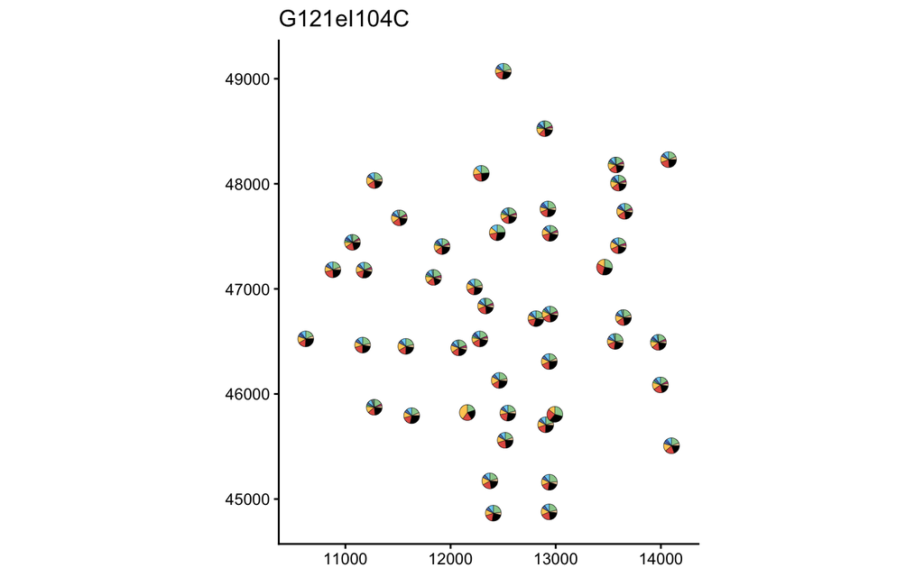

```r
lawsonibacter_piecharts$G121eI104C
```

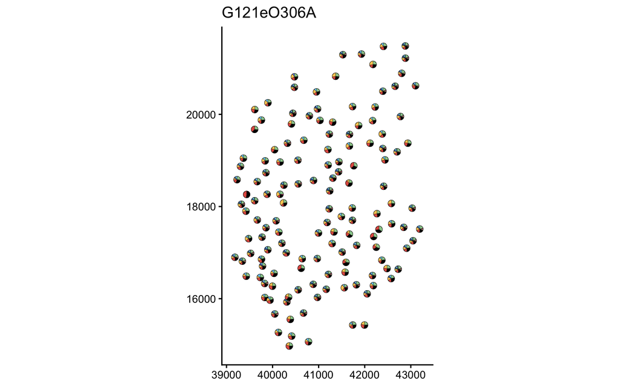

```r
lawsonibacter_piecharts$G121eO306A
```